# Modelos ARIMA intradía, regresión, datos de panel y GARCH para un portafolio de acciones del S&P 500

Programación y modelación financiera — Maestría en Finanzas

Fernanda Enríquez

10/11/2026

# 1 Planteamiento

**Objetivo.** Reconocer y aplicar modelos autorregresivos, integrados y de promedios móviles (**ARIMA**) en dos frecuencias intradía:

- **5 minutos** (alta frecuencia) y
- **horas seleccionadas cada 2 horas** (10:00, 12:00, 14:00 y 16:00, hora de Nueva York),

sobre cinco acciones del S&P 500 con buen rendimiento que **no** son las típicas (no son las “7 Magníficas” ni las más usadas en clase). Después se usan los modelos para construir y gestionar un portafolio con un capital de **USD 943,990.81**.

El documento integra lo visto en clase:

| Bloque | Método | Paquetes |
| --- | --- | --- |
| Regresión lineal simple | Modelo de mercado (CAPM): rendimiento de la acción vs. S&P 500 | `stats` |
| Regresión lineal múltiple | Rendimiento vs. mercado, VIX, tasa a 10 años, petróleo y dólar. Supuestos: VIF, Breusch-Pagan, Goldfeld-Quandt, Durbin-Watson | `car`, `lmtest`, `sandwich` |
| Datos de panel | Reportes trimestrales: ¿qué factores financieros explican superar al S&P 500? | `plm` |
| Series de tiempo | ARIMA de 5 min y de 2 horas con pronóstico | `forecast`, `tseries` |
| GARCH (puntos extra) | Volatilidad condicional y VaR | `rugarch` |
| Portafolio | Optimización media-varianza, número de acciones, estrategias y backtest | `PerformanceAnalytics` |

# 2 Librerías y parámetros

```r
paquetes <- c("quantmod", "xts", "zoo", "dplyr", "tidyr", "tibble", "purrr",
              "readr", "lubridate", "ggplot2", "forecast", "tseries", "rugarch",
              "plm", "lmtest", "sandwich", "car", "PerformanceAnalytics", "knitr")
faltantes <- paquetes[!paquetes %in% rownames(installed.packages())]
if (length(faltantes) > 0) install.packages(faltantes)
invisible(lapply(paquetes, library, character.only = TRUE))
```

`quantmod` descarga precios (respaldo cuando no hay archivo de Refinitiv), `xts`/`zoo` manejan series de tiempo, `dplyr`/`tidyr` manipulan tablas, `forecast` y `tseries` estiman y prueban modelos ARIMA, `rugarch` estima modelos GARCH, `plm` estima modelos de panel, `lmtest`, `sandwich` y `car` aportan las pruebas de supuestos y los errores robustos, y `PerformanceAnalytics` evalúa el portafolio.

```r
# ---------------- Parámetros generales ----------------
CAPITAL      <- 943990.81             # capital a invertir (USD)
RF_ANUAL     <- 0.04                  # tasa libre de riesgo anual (T-Bill 3m; en Refinitiv: US3MT=RR)
PRIMA_MDO    <- 0.055                 # prima de riesgo de mercado para el CAPM
FECHA_INICIO <- as.Date("2019-11-29") # misma fecha base que en clase
FECHA_FIN    <- Sys.Date()

# Carpeta con los CSV exportados de Refinitiv (relativa a este Rmd o ruta completa,
# p. ej. "C:/Users/Fernanda/Documents/proyecto/data")
RUTA_DATOS   <- "data"
ARCHIVO_FUND <- file.path(RUTA_DATOS, "fundamentales_trimestrales.csv")

# Fuente de precios diarios:
#  "refinitiv" -> usa data/diario/<TICKER>.csv y marca error si falta alguno
#  "auto"      -> usa el CSV si existe; si no, descarga de Yahoo (quantmod)
#  "yahoo"     -> sólo Yahoo
FUENTE_DIARIA <- "refinitiv"

# Datos intradía exportados de Refinitiv (ver sección 3)
TZ_ARCHIVO     <- "America/Mexico_City"  # zona horaria de los CSV: el Excel de Workspace exporta en hora
                                         # de México; el script de Python guarda en "UTC"
ETIQUETA_BARRA <- "fin"   # "fin" si la marca de tiempo es el CIERRE de la barra (LSEG por defecto),
                          # "inicio" si es la apertura (ver diagnóstico en la sección 3)
DIAS_5MIN      <- 20      # días hábiles más recientes que se usan para el ARIMA de 5 min
HORAS_2H       <- c(10, 12, 14, 16)  # horas seleccionadas (Nueva York)
H_5MIN         <- 12      # pronóstico: 12 barras de 5 min = 1 hora
H_2H           <- 4       # pronóstico: 4 observaciones de 2 h = 1 día de operación
COSTO_TRADE    <- 0.0005  # costo por operación (5 pb) para los backtests

# ---------------- Universo ----------------
universo <- tibble::tribble(
  ~ticker, ~ric,      ~empresa,              ~sector,                       ~grupo,
  "STX",   "STX.OQ",  "Seagate Technology",  "Tecnología (almacenamiento)", "Selección",
  "VLO",   "VLO.N",   "Valero Energy",       "Energía (refinación)",        "Selección",
  "DGX",   "DGX.N",   "Quest Diagnostics",   "Salud (diagnóstico)",         "Selección",
  "NUE",   "NUE.N",   "Nucor",               "Materiales (acero)",          "Selección",
  "CPAY",  "CPAY.N",  "Corpay",              "Financiero (pagos)",          "Selección",
  "AAPL",  "AAPL.OQ", "Apple",               "Tecnología",                  "Clase",
  "MSFT",  "MSFT.OQ", "Microsoft",           "Tecnología",                  "Clase",
  "JPM",   "JPM.N",   "JPMorgan Chase",      "Financiero",                  "Clase",
  "KO",    "KO.N",    "Coca-Cola",           "Consumo básico",              "Clase",
  "XOM",   "XOM.N",   "Exxon Mobil",         "Energía",                     "Clase"
)
SELECCION <- universo$ticker[universo$grupo == "Selección"]  # 5 acciones para ARIMA y portafolio
TODAS     <- universo$ticker                                  # 10 acciones para regresión y panel

factores <- tibble::tribble(
  ~nombre,    ~yahoo,     ~ric,
  "mercado",  "^GSPC",    ".SPX",
  "vix",      "^VIX",     ".VIX",
  "tasa10",   "^TNX",     "US10YT=RR",
  "petroleo", "BZ=F",     "LCOc1",   # Brent (el WTI fue negativo en abril de 2020)
  "dolar",    "DX-Y.NYB", ".DXY"
)
knitr::kable(universo, caption = "Universo de acciones (RIC = código de Refinitiv)")
```

Universo de acciones (RIC = código de Refinitiv)

| ticker | ric | empresa | sector | grupo |
| --- | --- | --- | --- | --- |
| STX | STX.OQ | Seagate Technology | Tecnología (almacenamiento) | Selección |
| VLO | VLO.N | Valero Energy | Energía (refinación) | Selección |
| DGX | DGX.N | Quest Diagnostics | Salud (diagnóstico) | Selección |
| NUE | NUE.N | Nucor | Materiales (acero) | Selección |
| CPAY | CPAY.N | Corpay | Financiero (pagos) | Selección |
| AAPL | AAPL.OQ | Apple | Tecnología | Clase |
| MSFT | MSFT.OQ | Microsoft | Tecnología | Clase |
| JPM | JPM.N | JPMorgan Chase | Financiero | Clase |
| KO | KO.N | Coca-Cola | Consumo básico | Clase |
| XOM | XOM.N | Exxon Mobil | Energía | Clase |

# 3 Selección de las cinco acciones

Se buscaron empresas del S&P 500 con rendimiento destacado en 2026 que **no** sean las más comentadas (Apple, Microsoft, Nvidia, Amazon, Alphabet, Meta, Tesla) y que pertenezcan a **sectores distintos**, para que el portafolio no dependa de un solo motor:

| Acción | Sector | Por qué |
| --- | --- | --- |
| **Seagate (STX)** | Tecnología – almacenamiento | Beneficiaria directa de la demanda de almacenamiento para centros de datos de IA, sin ser un nombre “Magnífico”. Es la de mayor crecimiento y mayor volatilidad, por eso recibe el menor peso. |
| **Valero (VLO)** | Energía – refinación | Los márgenes de refinación se dispararon en 2026. Fuerte generación de flujo de caja libre y recompras. Cubre al portafolio ante choques del petróleo. |
| **Quest Diagnostics (DGX)** | Salud – diagnóstico | Defensiva y de baja beta. Reportes por encima de lo esperado y máximos históricos. Estabiliza el portafolio. |
| **Nucor (NUE)** | Materiales – acero | Aranceles de la Sección 232 y demanda de acero para centros de datos. Utilidades en fuerte alza y 50 años de dividendos crecientes. |
| **Corpay (CPAY)** | Financiero – pagos corporativos | Ingresos recurrentes por comisiones, márgenes operativos altos y crecimiento constante. Diversifica fuera de las materias primas. |

Las otras cinco (AAPL, MSFT, JPM, KO y XOM) vienen de la actividad de datos de panel de clase y sirven como **grupo de control** para las regresiones y el panel (mínimo 10 acciones).

La selección se valida con las **mismas razones financieras de la actividad de panel** (ROE, margen operativo, flujo de caja libre, deuda/capital, crecimiento de ventas, volatilidad y *outperformance* contra el S&P 500) en la sección 5.

# 4 Extracción de datos desde Refinitiv (LSEG Workspace)

> Refinitiv Workspace/Eikon ahora se llama **LSEG Workspace**. La aplicación de escritorio debe estar **abierta y con sesión iniciada** para extraer datos por API.

**Opción A – Script de Python incluido (recomendada).** Con Workspace abierto, en la terminal:

```
pip install lseg-data pandas
python extraer_refinitiv.py
```

El script guarda los archivos con el formato que espera este documento:

- `data/diario/<TICKER>.csv` y `data/diario/<factor>.csv` (Date, Open, High, Low, Close, Volume)
- `data/intradia/<TICKER>_5min.csv` y `data/intradia/<TICKER>_60min.csv`
- `data/fundamentales_trimestrales.csv`

**Opción B – Manual desde la aplicación (sin programar).**

1. En la barra de búsqueda escribe el RIC (por ejemplo `STX.OQ`) y abre **Price History** (`PH`) o **Chart**.
2. Elige el intervalo **5 Minutes** y el rango (los últimos 20–60 días). Exporta con **Export → Excel**.
3. Repite con intervalo **1 Hour / 60 Minutes** y el mayor rango disponible (las horas 10, 12, 14 y 16 se seleccionan aquí en R).
4. Para precios diarios usa el intervalo **Daily** desde el 29/11/2019.
5. Para los reportes trimestrales abre **Financials** (`FA`) → **Income Statement / Balance Sheet / Cash Flow** → frecuencia **Quarterly** → exporta, o en Excel con el complemento de Workspace usa **Build Formula** con los campos `TR.F.TotRevenue`, `TR.F.OpProfBefNonRecurIncExpn`, `TR.F.NetIncAfterMinInt`, `TR.F.ShHoldEqParentShHoldTot`, `TR.F.DebtTot`, `TR.F.NetCashFlowOp` y `TR.F.CAPEXTot` (parámetros `Period=FQ0, Frq=FQ, SDate=0, EDate=-15`). Confirma los códigos en **Data Item Browser (DIB)**.
6. Guarda cada hoja como CSV con encabezados `Date, Open, High, Low, Close, Volume` en las carpetas de arriba.

```r
# ---- Lectura genérica de un CSV de precios (Refinitiv / Excel) ----
leer_csv_precio <- function(ruta, intradia = FALSE) {
  df <- readr::read_csv(ruta, show_col_types = FALSE)
  names(df) <- tolower(trimws(names(df)))
  col_f <- intersect(c("date", "fecha", "timestamp", "datetime", "date_time", "time"), names(df))[1]
  col_c <- intersect(c("close", "cierre", "trdprc_1", "close price", "price close",
                       "b_yld_1", "value"), names(df))[1]
  if (is.na(col_f) || is.na(col_c)) stop("Revisa los encabezados de ", ruta)
  f <- df[[col_f]]
  if (intradia) {
    if (inherits(f, "POSIXct")) {
      f <- lubridate::force_tz(f, TZ_ARCHIVO)
    } else {
      f <- lubridate::parse_date_time(as.character(f), tz = TZ_ARCHIVO,
             orders = c("Ymd HMS", "Ymd HM", "dmY HMS", "dmY HM", "mdY HMS", "mdY HM"))
    }
  } else {
    f <- as.Date(lubridate::parse_date_time(as.character(f),
             orders = c("Ymd", "Ymd HMS", "dmY", "mdY")))
  }
  x <- xts::xts(suppressWarnings(as.numeric(df[[col_c]])), order.by = f)
  colnames(x) <- "Close"
  x <- x[!is.na(x)]
  x[!duplicated(index(x))]
}

# ---- Trimestre como texto "2025-Q3" (sirve para unir tablas y como índice del panel) ----
trim_chr <- function(d) format(zoo::as.yearqtr(as.Date(d)), "%Y-Q%q")

# ---- Rendimiento anualizado, Sharpe y máxima caída ----
resumen_desempeno <- function(R) {
  tab <- as.data.frame(PerformanceAnalytics::table.AnnualizedReturns(R, Rf = RF_ANUAL / 252))
  tab["Máxima caída", ] <- as.numeric(PerformanceAnalytics::maxDrawdown(R))
  tab
}

# ---- Precios diarios: Refinitiv (CSV) o Yahoo ----
obtener_diario <- function(simbolo_yahoo, archivo) {
  ruta <- file.path(RUTA_DATOS, "diario", paste0(archivo, ".csv"))
  if (FUENTE_DIARIA %in% c("auto", "refinitiv") && file.exists(ruta)) {
    return(leer_csv_precio(ruta))
  }
  if (FUENTE_DIARIA == "refinitiv") stop("No existe ", ruta)
  y <- quantmod::getSymbols(simbolo_yahoo, src = "yahoo", from = FECHA_INICIO,
                            to = FECHA_FIN, auto.assign = FALSE)
  x <- na.omit(quantmod::Ad(y))
  colnames(x) <- "Close"
  x
}
```

```r
# Inventario de los CSV de Refinitiv: confirma que R los encuentra y qué periodo cubren
csv <- list.files(RUTA_DATOS, pattern = "\\.csv$", recursive = TRUE, full.names = TRUE)
if (length(csv) == 0) stop("No hay archivos CSV en '", RUTA_DATOS, "'. Revisa RUTA_DATOS.")
inventario <- purrr::map_dfr(csv, function(f) {
  d <- readr::read_csv(f, show_col_types = FALSE)
  col_f <- intersect(c("Date", "fecha"), names(d))[1]
  tibble(archivo = sub(paste0("^", RUTA_DATOS, "/"), "", f), filas = nrow(d),
         columnas = paste(names(d), collapse = ", "),
         desde = as.character(min(d[[col_f]], na.rm = TRUE)),
         hasta = as.character(max(d[[col_f]], na.rm = TRUE)))
})
faltan <- c(file.path("diario", paste0(c(TODAS, factores$nombre), ".csv")),
            file.path("intradia", paste0(rep(SELECCION, each = 2), c("_5min.csv", "_60min.csv"))),
            "fundamentales_trimestrales.csv")
faltan <- faltan[!faltan %in% inventario$archivo]
if (length(faltan) > 0) message("Faltan: ", paste(faltan, collapse = ", "))
knitr::kable(inventario, caption = sprintf("Archivos de Refinitiv encontrados en '%s' (%d)", RUTA_DATOS, nrow(inventario)))
```

Archivos de Refinitiv encontrados en ‘data’ (26)

| archivo | filas | columnas | desde | hasta |
| --- | --- | --- | --- | --- |
| diario/AAPL.csv | 1745 | Date, Open, High, Low, Close, Volume | 2019-11-29 | 2026-11-09 |
| diario/CPAY.csv | 1745 | Date, Open, High, Low, Close, Volume | 2019-11-29 | 2026-11-09 |
| diario/DGX.csv | 1745 | Date, Open, High, Low, Close, Volume | 2019-11-29 | 2026-11-09 |
| diario/dolar.csv | 1802 | Date, Open, High, Low, Close, Volume | 2019-11-29 | 2026-11-09 |
| diario/JPM.csv | 1745 | Date, Open, High, Low, Close, Volume | 2019-11-29 | 2026-11-09 |
| diario/KO.csv | 1745 | Date, Open, High, Low, Close, Volume | 2019-11-29 | 2026-11-09 |
| diario/mercado.csv | 1745 | Date, Open, High, Low, Close, Volume | 2019-11-29 | 2026-11-09 |
| diario/MSFT.csv | 1745 | Date, Open, High, Low, Close, Volume | 2019-11-29 | 2026-11-09 |
| diario/NUE.csv | 1745 | Date, Open, High, Low, Close, Volume | 2019-11-29 | 2026-11-09 |
| diario/petroleo.csv | 1793 | Date, Open, High, Low, Close, Volume | 2019-11-29 | 2026-11-09 |
| diario/STX.csv | 1745 | Date, Open, High, Low, Close, Volume | 2019-11-29 | 2026-11-09 |
| diario/tasa10.csv | 1737 | Date, Open, High, Low, Close, Volume | 2019-11-29 | 2026-11-09 |
| diario/vix.csv | 1778 | Date, Open, High, Low, Close, Volume | 2019-11-29 | 2026-11-09 |
| diario/VLO.csv | 1745 | Date, Open, High, Low, Close, Volume | 2019-11-29 | 2026-11-09 |
| diario/XOM.csv | 1745 | Date, Open, High, Low, Close, Volume | 2019-11-29 | 2026-11-09 |
| fundamentales_trimestrales.csv | 200 | ticker, fecha, ingresos, utilidad_operativa, capital_contable, deuda_total, flujo_operativo, capex | 2021-12-25 | 2026-10-03 |
| intradia/CPAY_5min.csv | 3554 | Date, Open, High, Low, Close, Volume | 2026-09-01 07:35:00 | 2026-11-10 12:10:00 |
| intradia/CPAY_60min.csv | 2507 | Date, Open, High, Low, Close, Volume | 2025-11-10 09:00:00 | 2026-11-10 13:00:00 |
| intradia/DGX_5min.csv | 3424 | Date, Open, High, Low, Close, Volume | 2026-09-01 07:35:00 | 2026-11-10 11:55:00 |
| intradia/DGX_60min.csv | 2506 | Date, Open, High, Low, Close, Volume | 2025-11-10 09:00:00 | 2026-11-10 13:00:00 |
| intradia/NUE_5min.csv | 3767 | Date, Open, High, Low, Close, Volume | 2026-09-01 07:35:00 | 2026-11-10 12:10:00 |
| intradia/NUE_60min.csv | 2506 | Date, Open, High, Low, Close, Volume | 2025-11-10 09:00:00 | 2026-11-10 13:00:00 |
| intradia/STX_5min.csv | 8579 | Date, Open, High, Low, Close, Volume | 2026-09-01 02:10:00 | 2026-11-10 12:10:00 |
| intradia/STX_60min.csv | 4002 | Date, Open, High, Low, Close, Volume | 2025-11-10 04:00:00 | 2026-11-10 13:00:00 |
| intradia/VLO_5min.csv | 4031 | Date, Open, High, Low, Close, Volume | 2026-09-01 07:35:00 | 2026-11-10 12:10:00 |
| intradia/VLO_60min.csv | 2506 | Date, Open, High, Low, Close, Volume | 2025-11-10 09:00:00 | 2026-11-10 13:00:00 |

```r
precios <- do.call(merge, lapply(TODAS, function(t) {
  x <- obtener_diario(t, t); colnames(x) <- t; x
}))
precios <- na.locf(precios, na.rm = FALSE)
precios <- precios[paste0(FECHA_INICIO, "/")]

fac_niveles <- do.call(merge, lapply(seq_len(nrow(factores)), function(i) {
  x <- obtener_diario(factores$yahoo[i], factores$nombre[i])
  colnames(x) <- factores$nombre[i]; x
}))

# Rendimientos logarítmicos diarios de las acciones
rend <- na.omit(diff(log(precios)))

# Cambios diarios de los factores
fac <- merge(diff(log(fac_niveles$mercado)),
             diff(log(fac_niveles$vix)),
             diff(fac_niveles$tasa10),           # cambio en puntos porcentuales
             diff(log(fac_niveles$petroleo)),
             diff(log(fac_niveles$dolar)))
colnames(fac) <- c("mercado", "vix", "tasa10", "petroleo", "dolar")

datos_d <- na.omit(merge(rend, fac))
dd <- data.frame(fecha = index(datos_d), coredata(datos_d))
cat("Observaciones diarias:", nrow(dd), " | del", format(min(dd$fecha)), "al", format(max(dd$fecha)), "\n")
```

```
## Observaciones diarias: 1662  | del 2019-12-02 al 2026-11-09
```

```r
head(dd)
```

|  | fecha | STX | VLO | DGX | NUE | CPAY | AAPL | MSFT | JPM | KO | XOM | mercado | vix | tasa10 | petroleo | dolar |
| --- | --- | --- | --- | --- | --- | --- | --- | --- | --- | --- | --- | --- | --- | --- | --- | --- |
| 1 | 2019-12-02 | -0.005882 | 0.001151 | -0.0004694 | 0.004956 | 0.004875 | -0.011630 | -0.0121624 | -0.002203 | 0.0065329 | 0.004248 | -0.008669 | 0.16675 | 0.060 | -0.024484 | -0.0042523 |
| 2 | 2019-12-03 | -0.019058 | -0.018049 | -0.0083919 | -0.024304 | -0.008270 | -0.017991 | -0.0016061 | -0.012938 | 0.0009298 | -0.007924 | -0.006660 | 0.06805 | -0.127 | -0.001643 | -0.0012168 |
| 3 | 2019-12-04 | 0.007360 | -0.007269 | 0.0065122 | 0.009900 | 0.001078 | 0.008788 | 0.0036101 | 0.019534 | 0.0090666 | 0.011280 | 0.006304 | -0.07546 | 0.072 | 0.035216 | -0.0009110 |
| 4 | 2019-12-05 | -0.000853 | -0.002363 | -0.0014121 | 0.011752 | -0.009944 | 0.014564 | 0.0005337 | 0.005426 | -0.0018437 | -0.003502 | 0.001499 | -0.01910 | 0.014 | 0.006171 | -0.0024403 |
| 5 | 2019-12-06 | 0.006804 | 0.006645 | 0.0072277 | 0.019633 | 0.015059 | 0.019132 | 0.0120659 | 0.014771 | 0.0042353 | 0.015952 | 0.009094 | -0.06399 | 0.048 | 0.015652 | 0.0029727 |
| 6 | 2019-12-09 | -0.032214 | -0.011712 | -0.0159325 | 0.002427 | -0.016907 | -0.014099 | -0.0025733 | -0.004676 | -0.0064522 | 0.002156 | -0.003168 | 0.15226 | -0.012 | -0.002177 | -0.0005733 |

**Interpretación.** Cada fila es un día hábil con el rendimiento logarítmico de las 10 acciones y el cambio de los cinco factores. Se usan rendimientos y no precios porque los precios no son estacionarios. `na.omit` elimina los días en que algún mercado estuvo cerrado.

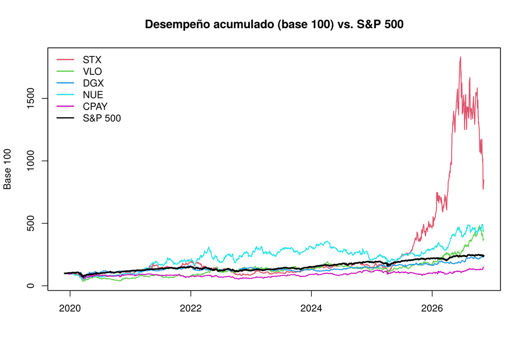

```r
p5      <- na.omit(precios[, SELECCION])
base100 <- xts(100 * t(t(coredata(p5)) / as.numeric(coredata(p5)[1, ])), index(p5))
m0      <- na.omit(fac_niveles$mercado[paste0(start(p5), "/")])
mkt100  <- 100 * m0 / as.numeric(m0[1])
plot.zoo(merge(base100, mkt100), plot.type = "single", col = c(2:6, 1), lwd = c(rep(1.5, 5), 2.5),
         main = "Desempeño acumulado (base 100) vs. S&P 500", xlab = "", ylab = "Base 100")
legend("topleft", legend = c(SELECCION, "S&P 500"), col = c(2:6, 1), lwd = 2, bty = "n")
```

# 5 Calidad de las empresas: razones de la actividad de panel

Se usan las mismas fórmulas de la actividad *¿Qué factores financieros se asocian con la capacidad de una acción para superar su índice de referencia?*:

- **ROE** = utilidad neta anualizada / capital contable
- **Margen operativo** = utilidad operativa / ingresos
- **Margen de flujo de caja libre** = (flujo operativo − |CAPEX|) / ingresos
- **Deuda/Capital** = deuda total / capital contable
- **Crecimiento de ventas** = ingresos del trimestre / ingresos del mismo trimestre del año anterior − 1
- **Volatilidad** = desviación estándar de los rendimientos diarios × √252
- **Outperformance** = rendimiento de la acción − rendimiento del S&P 500 en el mismo periodo

```r
HAY_FUND <- file.exists(ARCHIVO_FUND)
HAY_UTILIDAD <- HAY_FUND && "utilidad_neta" %in% names(readr::read_csv(ARCHIVO_FUND,
                                                                      n_max = 1, show_col_types = FALSE))
if (HAY_FUND && !HAY_UTILIDAD) message("El archivo de fundamentales no trae 'utilidad_neta' (TR.F.NetIncAfterMinInt): ",
                                       "el ROE se omite del scorecard y del panel.")
if (!HAY_FUND) message("No se encontró data/fundamentales_trimestrales.csv: corre extraer_refinitiv.py. ",
                       "Se omiten la tabla de calidad y el panel.")
```

```r
fund <- readr::read_csv(ARCHIVO_FUND, show_col_types = FALSE) %>%
  # Los trimestres fiscales pueden cerrar unos días después del fin del trimestre calendario
  # (p. ej. STX cierra el 2 de octubre): se restan 15 días para asignarlos al trimestre correcto
  mutate(fecha = as.Date(fecha), trimestre = trim_chr(fecha - 15)) %>%
  arrange(ticker, trimestre) %>%
  distinct(ticker, trimestre, .keep_all = TRUE) %>%
  group_by(ticker) %>%
  mutate(roe           = if (HAY_UTILIDAD) 4 * utilidad_neta / capital_contable else NA_real_,
         margen_op     = utilidad_operativa / ingresos,
         fcf_margen    = (flujo_operativo - abs(capex)) / ingresos,
         deuda_capital = deuda_total / capital_contable,
         crec_ventas   = ingresos / dplyr::lag(ingresos, 4) - 1) %>%
  ungroup()

# Rendimiento trimestral de cada acción y del S&P 500
pq   <- precios[endpoints(precios, "quarters")]
mq   <- fac_niveles$mercado[endpoints(fac_niveles$mercado, "quarters")]
rq   <- diff(log(pq)); rmq <- diff(log(mq))
ep   <- endpoints(rend, "quarters")
volq <- do.call(rbind, lapply(2:length(ep), function(i) {
  x <- rend[(ep[i - 1] + 1):ep[i]]
  xts(t(apply(coredata(x), 2, sd) * sqrt(252)), order.by = index(x)[NROW(x)])
}))

a_largo <- function(x, nombre) {
  data.frame(trimestre = trim_chr(index(x)), coredata(x), check.names = FALSE) %>%
    tidyr::pivot_longer(-trimestre, names_to = "ticker", values_to = nombre)
}
mercado_q <- data.frame(trimestre = trim_chr(index(rmq)), r_spx = as.numeric(rmq))

panel <- fund %>%
  inner_join(a_largo(rq, "r_accion"), by = c("ticker", "trimestre")) %>%
  inner_join(a_largo(volq, "volatilidad"), by = c("ticker", "trimestre")) %>%
  inner_join(mercado_q, by = "trimestre") %>%
  mutate(outperf = r_accion - r_spx) %>%
  filter(!HAY_UTILIDAD | is.finite(roe), is.finite(margen_op), is.finite(fcf_margen),
         is.finite(deuda_capital), is.finite(crec_ventas)) %>%
  mutate(periodo = trimestre)

cat("Panel:", n_distinct(panel$ticker), "empresas x", n_distinct(panel$periodo),
    "trimestres =", nrow(panel), "observaciones\n")
```

[output not shown]

```r
ultimo <- panel %>% group_by(ticker) %>% slice_max(trimestre, n = 1) %>% ungroup()
r1y <- sapply(TODAS, function(t) {
  x <- precios[, t]; as.numeric(xts::last(x)) / as.numeric(x[max(1, NROW(x) - 252)]) - 1
})
spx1y <- as.numeric(xts::last(fac_niveles$mercado)) /
         as.numeric(fac_niveles$mercado[NROW(fac_niveles$mercado) - 252]) - 1

score <- ultimo %>%
  transmute(ticker, trimestre, roe, margen_op, fcf_margen,
            deuda_capital, crec_ventas, volatilidad) %>%
  mutate(outperf_1a = r1y[ticker] - spx1y) %>%
  mutate(puntaje = ((if (HAY_UTILIDAD) rank(roe) else 0) + rank(margen_op) + rank(fcf_margen) +
                    rank(-deuda_capital) + rank(crec_ventas) + rank(-volatilidad) + rank(outperf_1a)) /
                   (6 + HAY_UTILIDAD)) %>%
  arrange(desc(puntaje)) %>%
  left_join(universo %>% select(ticker, grupo), by = "ticker")

knitr::kable(score %>% mutate(across(roe:outperf_1a, ~ round(.x * 100, 1)), puntaje = round(puntaje, 2)),
             caption = "Scorecard del último trimestre (cifras en %, salvo puntaje; deuda/capital en %)")
```

Scorecard del último trimestre (cifras en %, salvo puntaje; deuda/capital en %)

| ticker | trimestre | roe | margen_op | fcf_margen | deuda_capital | crec_ventas | volatilidad | outperf_1a | puntaje | grupo |
| --- | --- | --- | --- | --- | --- | --- | --- | --- | --- | --- |
| STX | 2026-Q3 | NA | 48.9 | 34.9 | 68.1 | 61.0 | 75.9 | 67.7 | 6.67 | Selección |
| VLO | 2026-Q3 | NA | 20.4 | 15.0 | 39.3 | 38.2 | 34.0 | 88.6 | 5.83 | Selección |
| XOM | 2026-Q3 | NA | 19.0 | 16.7 | 12.9 | 32.6 | 25.5 | 29.8 | 5.83 | Clase |
| MSFT | 2026-Q3 | NA | 49.8 | 20.2 | 22.6 | 18.8 | 37.9 | -4.4 | 5.17 | Clase |
| KO | 2026-Q3 | NA | 33.4 | 34.0 | 111.4 | 7.4 | 21.0 | 25.0 | 4.83 | Clase |
| CPAY | 2026-Q3 | NA | 44.7 | -53.2 | 340.7 | 17.9 | 24.6 | 50.6 | 4.50 | Selección |
| NUE | 2026-Q3 | NA | 16.7 | 14.3 | 31.1 | 32.0 | 35.1 | 58.2 | 4.50 | Selección |
| AAPL | 2026-Q3 | NA | 31.1 | 22.6 | 71.5 | 11.7 | 28.4 | 15.9 | 4.33 | Clase |
| DGX | 2026-Q3 | NA | 15.5 | 14.4 | 72.7 | 10.0 | 26.6 | 33.0 | 3.33 | Selección |

# 6 Regresión lineal simple: modelo de mercado (CAPM)

$$r_{i,t} = \beta_0 + \beta_1 \,
r_{SP500,t} + \varepsilon_t$$

$\beta_1$ (beta) mide la sensibilidad de la acción al mercado y $\beta_0$ (alfa) el rendimiento que no explica el mercado.

```r
tabla_rls <- purrr::map_dfr(TODAS, function(t) {
  m  <- lm(reformulate("mercado", response = t), data = dd)
  s  <- summary(m); cf <- coef(s)
  tibble(ticker = t, alfa_anual = cf[1, 1] * 252, p_alfa = cf[1, 4],
         beta = cf[2, 1], p_beta = cf[2, 4], R2 = s$r.squared,
         error_est = s$sigma, n = nobs(m))
})
knitr::kable(tabla_rls, digits = 4, caption = "Regresión lineal simple de cada acción contra el S&P 500")
```

Regresión lineal simple de cada acción contra el S&P 500

| ticker | alfa_anual | p_alfa | beta | p_beta | R2 | error_est | n |
| --- | --- | --- | --- | --- | --- | --- | --- |
| STX | 0.1476 | 0.3574 | 1.2081 | 0 | 0.2632 | 0.0259 | 1662 |
| VLO | 0.0637 | 0.6920 | 1.0284 | 0 | 0.2049 | 0.0260 | 1662 |
| DGX | 0.0959 | 0.2987 | 0.5104 | 0 | 0.1616 | 0.0149 | 1662 |
| NUE | 0.0788 | 0.5330 | 1.1463 | 0 | 0.3412 | 0.0204 | 1662 |
| CPAY | -0.0796 | 0.4589 | 1.1216 | 0 | 0.4067 | 0.0174 | 1662 |
| AAPL | 0.0844 | 0.2903 | 1.1437 | 0 | 0.5641 | 0.0129 | 1662 |
| MSFT | 0.0365 | 0.6380 | 1.1354 | 0 | 0.5742 | 0.0125 | 1662 |
| JPM | 0.0216 | 0.7991 | 1.0491 | 0 | 0.4912 | 0.0137 | 1662 |
| KO | 0.0414 | 0.5462 | 0.4934 | 0 | 0.2454 | 0.0111 | 1662 |
| XOM | 0.0456 | 0.6875 | 0.7114 | 0 | 0.1987 | 0.0183 | 1662 |

```r
interpretar_rls <- function(f) {
  sig  <- ifelse(f$p_beta < 0.05, "significativa", "no significativa")
  tipo <- ifelse(f$beta > 1, "agresiva (amplifica los movimientos del mercado)",
          ifelse(f$beta > 0, "defensiva (se mueve menos que el mercado)", "con relación inversa al mercado"))
  sprintf("- **%s**: beta = %.2f (%s, p = %.3g), es una acción %s. Si el S&P 500 sube 1%%, la acción sube en promedio %.2f%%. El mercado explica %.1f%% de su variación diaria (R²). Alfa anualizada = %.1f%% (%s).",
          f$ticker, f$beta, sig, f$p_beta, tipo, f$beta, 100 * f$R2, 100 * f$alfa_anual,
          ifelse(f$p_alfa < 0.05, "significativa", "no significativa"))
}
cat(sapply(seq_len(nrow(tabla_rls)), function(i) interpretar_rls(tabla_rls[i, ])), sep = "\n")
```

- **STX**: beta = 1.21 (significativa, p = 3.19e-112), es una acción agresiva (amplifica los movimientos del mercado). Si el S&P 500 sube 1%, la acción sube en promedio 1.21%. El mercado explica 26.3% de su variación diaria (R²). Alfa anualizada = 14.8% (no significativa).
- **VLO**: beta = 1.03 (significativa, p = 9.9e-85), es una acción agresiva (amplifica los movimientos del mercado). Si el S&P 500 sube 1%, la acción sube en promedio 1.03%. El mercado explica 20.5% de su variación diaria (R²). Alfa anualizada = 6.4% (no significativa).
- **DGX**: beta = 0.51 (significativa, p = 1.41e-65), es una acción defensiva (se mueve menos que el mercado). Si el S&P 500 sube 1%, la acción sube en promedio 0.51%. El mercado explica 16.2% de su variación diaria (R²). Alfa anualizada = 9.6% (no significativa).
- **NUE**: beta = 1.15 (significativa, p = 1.23e-152), es una acción agresiva (amplifica los movimientos del mercado). Si el S&P 500 sube 1%, la acción sube en promedio 1.15%. El mercado explica 34.1% de su variación diaria (R²). Alfa anualizada = 7.9% (no significativa).
- **CPAY**: beta = 1.12 (significativa, p = 1.93e-190), es una acción agresiva (amplifica los movimientos del mercado). Si el S&P 500 sube 1%, la acción sube en promedio 1.12%. El mercado explica 40.7% de su variación diaria (R²). Alfa anualizada = -8.0% (no significativa).
- **AAPL**: beta = 1.14 (significativa, p = 1.35e-301), es una acción agresiva (amplifica los movimientos del mercado). Si el S&P 500 sube 1%, la acción sube en promedio 1.14%. El mercado explica 56.4% de su variación diaria (R²). Alfa anualizada = 8.4% (no significativa).
- **MSFT**: beta = 1.14 (significativa, p = 4.73e-310), es una acción agresiva (amplifica los movimientos del mercado). Si el S&P 500 sube 1%, la acción sube en promedio 1.14%. El mercado explica 57.4% de su variación diaria (R²). Alfa anualizada = 3.7% (no significativa).
- **JPM**: beta = 1.05 (significativa, p = 8.19e-246), es una acción agresiva (amplifica los movimientos del mercado). Si el S&P 500 sube 1%, la acción sube en promedio 1.05%. El mercado explica 49.1% de su variación diaria (R²). Alfa anualizada = 2.2% (no significativa).
- **KO**: beta = 0.49 (significativa, p = 1.25e-103), es una acción defensiva (se mueve menos que el mercado). Si el S&P 500 sube 1%, la acción sube en promedio 0.49%. El mercado explica 24.5% de su variación diaria (R²). Alfa anualizada = 4.1% (no significativa).
- **XOM**: beta = 0.71 (significativa, p = 5.96e-82), es una acción defensiva (se mueve menos que el mercado). Si el S&P 500 sube 1%, la acción sube en promedio 0.71%. El mercado explica 19.9% de su variación diaria (R²). Alfa anualizada = 4.6% (no significativa).

Ejemplo detallado con intervalos de confianza y de predicción (como en la clase del 21 de septiembre) para la acción más agresiva:

```r
t_ej <- tabla_rls$ticker[which.max(tabla_rls$beta)]
modelo_rls <- lm(reformulate("mercado", response = t_ej), data = dd)
summary(modelo_rls)
```

```
##
## Call:
## lm(formula = reformulate("mercado", response = t_ej), data = dd)
##
## Residuals:
##      Min       1Q   Median       3Q      Max
## -0.13053 -0.01138  0.00034  0.01122  0.17468
##
## Coefficients:
##             Estimate Std. Error t value            Pr(>|t|)
## (Intercept) 0.000586   0.000636    0.92                0.36
## mercado     1.208142   0.049619   24.35 <0.0000000000000002 ***
## ---
## Signif. codes:  0 '***' 0.001 '**' 0.01 '*' 0.05 '.' 0.1 ' ' 1
##
## Residual standard error: 0.0259 on 1660 degrees of freedom
## Multiple R-squared:  0.263,  Adjusted R-squared:  0.263
## F-statistic:  593 on 1 and 1660 DF,  p-value: <0.0000000000000002
```

```r
confint(modelo_rls)
```

```
##                  2.5 %   97.5 %
## (Intercept) -0.0006624 0.001834
## mercado      1.1108197 1.305464
```

```r
nuevos <- data.frame(mercado = c(-0.02, 0, 0.02))
predict(modelo_rls, nuevos, interval = "confidence")
```

```
##          fit        lwr       upr
## 1 -0.0235770 -0.0259350 -0.021219
## 2  0.0005858 -0.0006624  0.001834
## 3  0.0247486  0.0224830  0.027014
```

```r
predict(modelo_rls, nuevos, interval = "prediction")
```

```
##          fit      lwr     upr
## 1 -0.0235770 -0.07447 0.02731
## 2  0.0005858 -0.05027 0.05144
## 3  0.0247486 -0.02614 0.07563
```

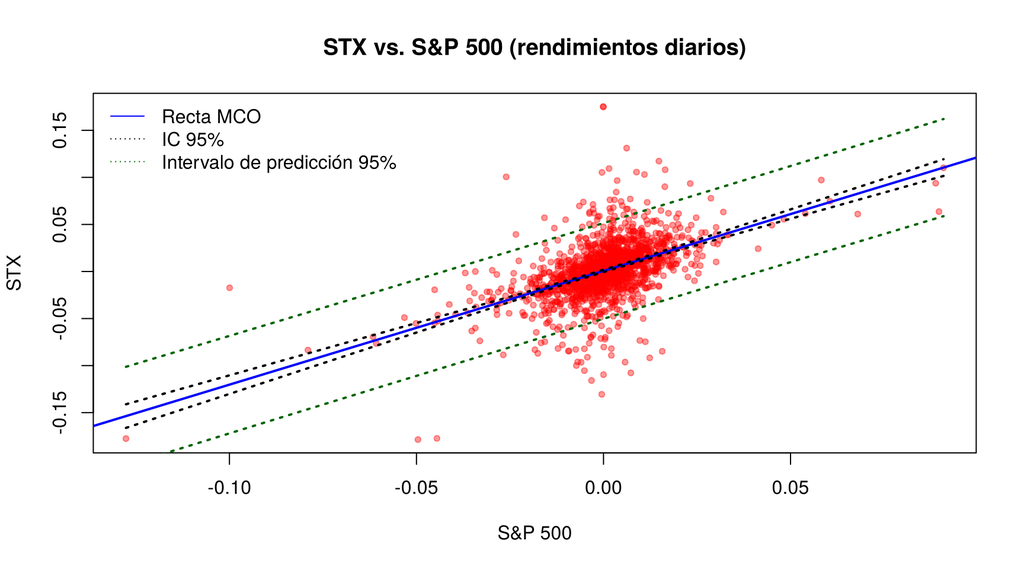

```r
orden <- order(dd$mercado)
ic <- predict(modelo_rls, dd[orden, ], interval = "confidence")
ip <- predict(modelo_rls, dd[orden, ], interval = "prediction")
plot(dd$mercado, dd[[t_ej]], pch = 20, col = adjustcolor("red", 0.4),
     main = paste(t_ej, "vs. S&P 500 (rendimientos diarios)"), xlab = "S&P 500", ylab = t_ej)
abline(modelo_rls, lwd = 2, col = "blue")
matlines(dd$mercado[orden], ic[, 2:3], col = "black", lty = 3, lwd = 2)
matlines(dd$mercado[orden], ip[, 2:3], col = "darkgreen", lty = 3, lwd = 2)
legend("topleft", c("Recta MCO", "IC 95%", "Intervalo de predicción 95%"),
       col = c("blue", "black", "darkgreen"), lty = c(1, 3, 3), bty = "n")
```

**Interpretación.** El intervalo de confianza (negro) es estrecho porque estima el rendimiento **promedio** dado el mercado. El de predicción (verde) es mucho más amplio porque incluye el ruido de un día individual. Por eso el mercado explica la dirección general, pero no el rendimiento exacto de un día.

# 7 Regresión lineal múltiple y supuestos

$$r_{i,t} = \beta_0 + \beta_1
\,\text{mercado}_t + \beta_2 \,\Delta\text{VIX}_t + \beta_3
\,\Delta\text{tasa10}_t + \beta_4 \,\text{petróleo}_t + \beta_5
\,\text{dólar}_t + \varepsilon_t$$

```r
form_rlm <- function(t) reformulate(c("mercado", "vix", "tasa10", "petroleo", "dolar"), response = t)
tabla_rlm <- purrr::map_dfr(TODAS, function(t) {
  m <- lm(form_rlm(t), data = dd); s <- summary(m); cf <- coef(s)
  f <- s$fstatistic
  tibble(ticker = t,
         b_mercado = cf["mercado", 1],  p_mercado = cf["mercado", 4],
         b_vix = cf["vix", 1],          p_vix = cf["vix", 4],
         b_tasa10 = cf["tasa10", 1],    p_tasa10 = cf["tasa10", 4],
         b_petroleo = cf["petroleo", 1], p_petroleo = cf["petroleo", 4],
         b_dolar = cf["dolar", 1],      p_dolar = cf["dolar", 4],
         R2_aj = s$adj.r.squared,
         p_F = pf(f[1], f[2], f[3], lower.tail = FALSE))
})
knitr::kable(tabla_rlm, digits = 4, caption = "Regresión múltiple de cada acción (coeficientes y valores p)")
```

Regresión múltiple de cada acción (coeficientes y valores p)

| ticker | b_mercado | p_mercado | b_vix | p_vix | b_tasa10 | p_tasa10 | b_petroleo | p_petroleo | b_dolar | p_dolar | R2_aj | p_F |
| --- | --- | --- | --- | --- | --- | --- | --- | --- | --- | --- | --- | --- |
| STX | 1.1342 | 0 | -0.0148 | 0.2086 | 0.0205 | 0.0809 | -0.0238 | 0.3020 | -0.1426 | 0.3779 | 0.2634 | 0 |
| VLO | 0.9529 | 0 | 0.0150 | 0.1719 | 0.0558 | 0.0000 | 0.3031 | 0.0000 | -0.1740 | 0.2486 | 0.3122 | 0 |
| DGX | 0.6639 | 0 | 0.0316 | 0.0000 | -0.0199 | 0.0028 | -0.0192 | 0.1444 | -0.0844 | 0.3591 | 0.1790 | 0 |
| NUE | 1.0919 | 0 | -0.0028 | 0.7612 | 0.0314 | 0.0006 | 0.0600 | 0.0009 | -0.1398 | 0.2697 | 0.3501 | 0 |
| CPAY | 1.1025 | 0 | 0.0038 | 0.6246 | 0.0117 | 0.1350 | 0.0729 | 0.0000 | -0.0874 | 0.4167 | 0.4151 | 0 |
| AAPL | 1.1864 | 0 | 0.0065 | 0.2689 | -0.0079 | 0.1741 | -0.0157 | 0.1715 | 0.0767 | 0.3403 | 0.5643 | 0 |
| MSFT | 1.1894 | 0 | 0.0070 | 0.2198 | -0.0051 | 0.3643 | -0.0297 | 0.0077 | 0.1599 | 0.0407 | 0.5763 | 0 |
| JPM | 1.0582 | 0 | 0.0100 | 0.0964 | 0.0560 | 0.0000 | 0.0245 | 0.0383 | -0.1419 | 0.0872 | 0.5208 | 0 |
| KO | 0.6234 | 0 | 0.0319 | 0.0000 | -0.0010 | 0.8372 | 0.0047 | 0.6278 | -0.2486 | 0.0003 | 0.2689 | 0 |
| XOM | 0.6260 | 0 | 0.0130 | 0.0621 | 0.0335 | 0.0000 | 0.3365 | 0.0000 | -0.1034 | 0.2810 | 0.4364 | 0 |

```r
for (i in seq_len(nrow(tabla_rlm))) {
  f <- tabla_rlm[i, ]
  vars <- c("mercado", "vix", "tasa10", "petroleo", "dolar")
  ps <- unlist(f[paste0("p_", vars)]); bs <- unlist(f[paste0("b_", vars)])
  sig <- vars[ps < 0.05]
  txt <- if (length(sig) == 0) "ninguna variable es significativa" else
    paste(sprintf("%s (%s)", sig, ifelse(bs[ps < 0.05] > 0, "+", "−")), collapse = ", ")
  cat(sprintf("- **%s**: variables significativas al 5%%: %s. R² ajustado = %.1f%%. En conjunto, el modelo %s es significativo (p de F = %.3g).\n",
              f$ticker, txt, 100 * f$R2_aj, ifelse(f$p_F < 0.05, "sí", "no"), f$p_F))
}
```

- **STX**: variables significativas al 5%: mercado (+). R² ajustado = 26.3%. En conjunto, el modelo sí es significativo (p de F = 2.48e-108).
- **VLO**: variables significativas al 5%: mercado (+), tasa10 (+), petroleo (+). R² ajustado = 31.2%. En conjunto, el modelo sí es significativo (p de F = 6.49e-133).
- **DGX**: variables significativas al 5%: mercado (+), vix (+), tasa10 (−). R² ajustado = 17.9%. En conjunto, el modelo sí es significativo (p de F = 1.36e-69).
- **NUE**: variables significativas al 5%: mercado (+), tasa10 (+), petroleo (+). R² ajustado = 35.0%. En conjunto, el modelo sí es significativo (p de F = 3.39e-153).
- **CPAY**: variables significativas al 5%: mercado (+), petroleo (+). R² ajustado = 41.5%. En conjunto, el modelo sí es significativo (p de F = 5.94e-191).
- **AAPL**: variables significativas al 5%: mercado (+). R² ajustado = 56.4%. En conjunto, el modelo sí es significativo (p de F = 1.16e-296).
- **MSFT**: variables significativas al 5%: mercado (+), petroleo (−), dolar (+). R² ajustado = 57.6%. En conjunto, el modelo sí es significativo (p de F = 1.13e-306).
- **JPM**: variables significativas al 5%: mercado (+), tasa10 (+), petroleo (+). R² ajustado = 52.1%. En conjunto, el modelo sí es significativo (p de F = 1.66e-262).
- **KO**: variables significativas al 5%: mercado (+), vix (+), dolar (−). R² ajustado = 26.9%. En conjunto, el modelo sí es significativo (p de F = 5.14e-111).
- **XOM**: variables significativas al 5%: mercado (+), tasa10 (+), petroleo (+). R² ajustado = 43.6%. En conjunto, el modelo sí es significativo (p de F = 2.64e-204).

## 7.1 Diagnóstico completo para Valero (sensible al petróleo)

```r
modelo_rlm <- lm(form_rlm("VLO"), data = dd)
summary(modelo_rlm)
```

```
##
## Call:
## lm(formula = form_rlm("VLO"), data = dd)
##
## Residuals:
##      Min       1Q   Median       3Q      Max
## -0.13217 -0.01267 -0.00034  0.01295  0.23124
##
## Coefficients:
##               Estimate Std. Error t value             Pr(>|t|)
## (Intercept)  0.0000975  0.0005932    0.16                 0.87
## mercado      0.9528798  0.0696271   13.69 < 0.0000000000000002 ***
## vix          0.0150015  0.0109755    1.37                 0.17
## tasa10       0.0558368  0.0109209    5.11           0.00000035 ***
## petroleo     0.3030583  0.0214936   14.10 < 0.0000000000000002 ***
## dolar       -0.1739887  0.1507516   -1.15                 0.25
## ---
## Signif. codes:  0 '***' 0.001 '**' 0.01 '*' 0.05 '.' 0.1 ' ' 1
##
## Residual standard error: 0.0241 on 1656 degrees of freedom
## Multiple R-squared:  0.314,  Adjusted R-squared:  0.312
## F-statistic:  152 on 5 and 1656 DF,  p-value: <0.0000000000000002
```

```r
# Selección de variables (como en clase: quitar las no significativas)
modelo_rlm2 <- step(modelo_rlm, trace = 0)
summary(modelo_rlm2)
```

```
##
## Call:
## lm(formula = VLO ~ mercado + tasa10 + petroleo, data = dd)
##
## Residuals:
##      Min       1Q   Median       3Q      Max
## -0.13525 -0.01263 -0.00072  0.01305  0.23202
##
## Coefficients:
##             Estimate Std. Error t value             Pr(>|t|)
## (Intercept) 0.000118   0.000593    0.20                 0.84
## mercado     0.895341   0.046978   19.06 < 0.0000000000000002 ***
## tasa10      0.050851   0.010153    5.01           0.00000061 ***
## petroleo    0.305164   0.021465   14.22 < 0.0000000000000002 ***
## ---
## Signif. codes:  0 '***' 0.001 '**' 0.01 '*' 0.05 '.' 0.1 ' ' 1
##
## Residual standard error: 0.0242 on 1658 degrees of freedom
## Multiple R-squared:  0.313,  Adjusted R-squared:  0.312
## F-statistic:  252 on 3 and 1658 DF,  p-value: <0.0000000000000002
```

```r
# Multicolinealidad
round(cor(dd[, c("mercado", "vix", "tasa10", "petroleo", "dolar")]), 2)
```

```
##          mercado   vix tasa10 petroleo dolar
## mercado     1.00 -0.73   0.07     0.17 -0.17
## vix        -0.73  1.00  -0.06    -0.09  0.12
## tasa10      0.07 -0.06   1.00     0.19  0.35
## petroleo    0.17 -0.09   0.19     1.00  0.02
## dolar      -0.17  0.12   0.35     0.02  1.00
```

```r
car::vif(modelo_rlm)
```

```
##  mercado      vix   tasa10 petroleo    dolar
##    2.268    2.178    1.203    1.067    1.195
```

```r
# Heterocedasticidad
lmtest::bptest(modelo_rlm)                                   # Breusch-Pagan
```

```
##
##  studentized Breusch-Pagan test
##
## data:  modelo_rlm
## BP = 2.5, df = 5, p-value = 0.8
```

```r
lmtest::gqtest(modelo_rlm, order.by = ~ mercado, data = dd)  # Goldfeld-Quandt
```

```
##
##  Goldfeld-Quandt test
##
## data:  modelo_rlm
## GQ = 1.1, df1 = 825, df2 = 825, p-value = 0.1
## alternative hypothesis: variance increases from segment 1 to 2
```

```r
# Autocorrelación
lmtest::dwtest(modelo_rlm)                                   # Durbin-Watson
```

```
##
##  Durbin-Watson test
##
## data:  modelo_rlm
## DW = 2, p-value = 0.6
## alternative hypothesis: true autocorrelation is greater than 0
```

```r
# Corrección: errores estándar robustos (HC1 de White)
lmtest::coeftest(modelo_rlm, vcov = sandwich::vcovHC(modelo_rlm, type = "HC1"))
```

```
##
## t test of coefficients:
##
##               Estimate Std. Error t value        Pr(>|t|)
## (Intercept)  0.0000975  0.0005971    0.16            0.87
## mercado      0.9528798  0.1375207    6.93 0.0000000000060 ***
## vix          0.0150015  0.0163497    0.92            0.36
## tasa10       0.0558368  0.0134719    4.14 0.0000357458842 ***
## petroleo     0.3030583  0.0408898    7.41 0.0000000000002 ***
## dolar       -0.1739887  0.1875024   -0.93            0.35
## ---
## Signif. codes:  0 '***' 0.001 '**' 0.01 '*' 0.05 '.' 0.1 ' ' 1
```

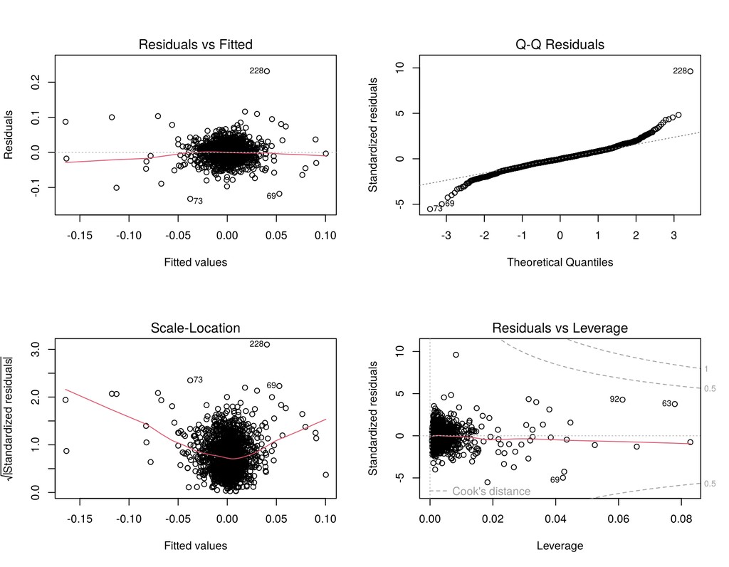

```r
par(mfrow = c(2, 2)); plot(modelo_rlm); par(mfrow = c(1, 1))
```

# 8 Datos de panel con reportes trimestrales

```r
fp <- if (HAY_UTILIDAD) outperf ~ roe + margen_op + fcf_margen + deuda_capital + crec_ventas + volatilidad else
                         outperf ~ margen_op + fcf_margen + deuda_capital + crec_ventas + volatilidad
pdat <- pdata.frame(panel, index = c("ticker", "periodo"))

panel_ols <- lm(fp, data = panel)                      # MCO ignorando el panel
panel_po  <- plm(fp, data = pdat, model = "pooling")   # agrupado
panel_fe  <- plm(fp, data = pdat, model = "within")    # efectos fijos
panel_re  <- tryCatch(plm(fp, data = pdat, model = "random"),
                      error = function(e) plm(fp, data = pdat, model = "random",
                                              random.method = "amemiya"))
summary(panel_po)
```

```
## Pooling Model
##
## Call:
## plm(formula = fp, data = pdat, model = "pooling")
##
## Balanced Panel: n = 9, T = 14, N = 126
##
## Residuals:
##     Min.  1st Qu.   Median  3rd Qu.     Max.
## -0.43368 -0.08869 -0.00587  0.08961  0.57116
##
## Coefficients:
##               Estimate Std. Error t-value Pr(>|t|)
## (Intercept)   -0.07522    0.04664   -1.61    0.109
## margen_op      0.02430    0.11978    0.20    0.840
## fcf_margen    -0.04220    0.06724   -0.63    0.531
## deuda_capital -0.00405    0.00187   -2.16    0.032 *
## crec_ventas    0.14777    0.09416    1.57    0.119
## volatilidad    0.30106    0.11723    2.57    0.011 *
## ---
## Signif. codes:  0 '***' 0.001 '**' 0.01 '*' 0.05 '.' 0.1 ' ' 1
##
## Total Sum of Squares:    3.36
## Residual Sum of Squares: 2.89
## R-Squared:      0.14
## Adj. R-Squared: 0.104
## F-statistic: 3.89278 on 5 and 120 DF, p-value: 0.00264
```

```r
summary(panel_fe)
```

```
## Oneway (individual) effect Within Model
##
## Call:
## plm(formula = fp, data = pdat, model = "within")
##
## Balanced Panel: n = 9, T = 14, N = 126
##
## Residuals:
##     Min.  1st Qu.   Median  3rd Qu.     Max.
## -0.39703 -0.08286 -0.00567  0.09601  0.49702
##
## Coefficients:
##               Estimate Std. Error t-value Pr(>|t|)
## margen_op      0.42439    0.29013    1.46     0.15
## fcf_margen    -0.03482    0.07045   -0.49     0.62
## deuda_capital -0.00321    0.00214   -1.50     0.14
## crec_ventas    0.06750    0.10998    0.61     0.54
## volatilidad    0.16444    0.18120    0.91     0.37
##
## Total Sum of Squares:    3.09
## Residual Sum of Squares: 2.81
## R-Squared:      0.09
## Adj. R-Squared: -0.0156
## F-statistic: 2.21636 on 5 and 112 DF, p-value: 0.0575
```

```r
summary(panel_re)
```

```
## Oneway (individual) effect Random Effect Model
##    (Swamy-Arora's transformation)
##
## Call:
## plm(formula = fp, data = pdat, model = "random")
##
## Balanced Panel: n = 9, T = 14, N = 126
##
## Effects:
##                  var std.dev share
## idiosyncratic 0.0251  0.1585     1
## individual    0.0000  0.0000     0
## theta: 0
##
## Residuals:
##     Min.  1st Qu.   Median  3rd Qu.     Max.
## -0.43368 -0.08869 -0.00587  0.08961  0.57116
##
## Coefficients:
##               Estimate Std. Error z-value Pr(>|z|)
## (Intercept)   -0.07522    0.04664   -1.61    0.107
## margen_op      0.02430    0.11978    0.20    0.839
## fcf_margen    -0.04220    0.06724   -0.63    0.530
## deuda_capital -0.00405    0.00187   -2.16    0.031 *
## crec_ventas    0.14777    0.09416    1.57    0.117
## volatilidad    0.30106    0.11723    2.57    0.010 *
## ---
## Signif. codes:  0 '***' 0.001 '**' 0.01 '*' 0.05 '.' 0.1 ' ' 1
##
## Total Sum of Squares:    3.36
## Residual Sum of Squares: 2.89
## R-Squared:      0.14
## Adj. R-Squared: 0.104
## Chisq: 19.4639 on 5 DF, p-value: 0.00157
```

```r
prueba_F   <- pFtest(panel_fe, panel_po)               # agrupado vs. efectos fijos
prueba_BP  <- plmtest(panel_po, type = "bp")           # agrupado vs. efectos aleatorios
hausman    <- phtest(panel_fe, panel_re)               # efectos fijos vs. aleatorios
wooldridge <- pwartest(panel_fe)                       # autocorrelación serial
pesaran    <- pcdtest(panel_fe, test = "cd")           # dependencia transversal
prueba_F; prueba_BP; hausman; wooldridge; pesaran
```

```
##
##  F test for individual effects
##
## data:  fp
## F = 0.39, df1 = 8, df2 = 112, p-value = 0.9
## alternative hypothesis: significant effects
```

```
##
##  Lagrange Multiplier Test - (Breusch-Pagan)
##
## data:  fp
## chisq = 3.7, df = 1, p-value = 0.05
## alternative hypothesis: significant effects
```

```
##
##  Hausman Test
##
## data:  fp
## chisq = 2.6, df = 5, p-value = 0.8
## alternative hypothesis: one model is inconsistent
```

```
##
##  Wooldridge's test for serial correlation in FE panels
##
## data:  panel_fe
## F = 5.5, df1 = 1, df2 = 115, p-value = 0.02
## alternative hypothesis: serial correlation
```

```
##
##  Pesaran CD test for cross-sectional dependence in panels
##
## data:  outperf ~ margen_op + fcf_margen + deuda_capital + crec_ventas +     volatilidad
## z = 0.93, p-value = 0.4
## alternative hypothesis: cross-sectional dependence
```

```r
# Elección automática del modelo
modelo_panel <- if (prueba_F$p.value >= 0.05 && prueba_BP$p.value >= 0.05) panel_po else
                if (hausman$p.value < 0.05) panel_fe else panel_re
nombre_panel <- if (identical(modelo_panel, panel_po)) "agrupado (pooled)" else
                if (identical(modelo_panel, panel_fe)) "efectos fijos" else "efectos aleatorios"

# Errores robustos: Arellano (cluster por empresa) y Driscoll-Kraay (dependencia transversal)
coeftest(modelo_panel, vcov = vcovHC(modelo_panel, method = "arellano", type = "HC1"))
```

```
##
## t test of coefficients:
##
##                Estimate Std. Error t value            Pr(>|t|)
## (Intercept)   -0.075220   0.058395   -1.29               0.200
## margen_op      0.024300   0.085056    0.29               0.776
## fcf_margen    -0.042198   0.042083   -1.00               0.318
## deuda_capital -0.004054   0.000163  -24.83 <0.0000000000000002 ***
## crec_ventas    0.147768   0.085038    1.74               0.085 .
## volatilidad    0.301064   0.172685    1.74               0.084 .
## ---
## Signif. codes:  0 '***' 0.001 '**' 0.01 '*' 0.05 '.' 0.1 ' ' 1
```

```r
coeftest(modelo_panel, vcov = vcovSCC(modelo_panel, type = "HC1"))
```

```
##
## t test of coefficients:
##
##                Estimate Std. Error t value Pr(>|t|)
## (Intercept)   -0.075220   0.056811   -1.32    0.188
## margen_op      0.024300   0.161542    0.15    0.881
## fcf_margen    -0.042198   0.057237   -0.74    0.462
## deuda_capital -0.004054   0.000932   -4.35 0.000029 ***
## crec_ventas    0.147768   0.099193    1.49    0.139
## volatilidad    0.301064   0.143978    2.09    0.039 *
## ---
## Signif. codes:  0 '***' 0.001 '**' 0.01 '*' 0.05 '.' 0.1 ' ' 1
```

```r
ct  <- coeftest(modelo_panel, vcov = vcovSCC(modelo_panel, type = "HC1"))
sig <- rownames(ct)[ct[, 4] < 0.05 & rownames(ct) != "(Intercept)"]
cat(sprintf("- **Prueba F** (p = %.3g): %s.\n", prueba_F$p.value,
            ifelse(prueba_F$p.value < 0.05, "hay efectos individuales; el modelo agrupado no basta",
                   "no hay evidencia de efectos individuales")))
```

- **Prueba F** (p = 0.924): no hay evidencia de efectos individuales.

```r
cat(sprintf("- **Hausman** (p = %.3g): %s.\n", hausman$p.value,
            ifelse(hausman$p.value < 0.05, "se prefieren efectos fijos", "efectos aleatorios es consistente y más eficiente")))
```

- **Hausman** (p = 0.765): efectos aleatorios es consistente y más eficiente.

```r
cat(sprintf("- **Wooldridge** (p = %.3g): %s autocorrelación serial.\n", wooldridge$p.value,
            ifelse(wooldridge$p.value < 0.05, "hay", "no hay evidencia de")))
```

- **Wooldridge** (p = 0.0207): hay autocorrelación serial.

```r
cat(sprintf("- **Pesaran CD** (p = %.3g): %s dependencia transversal; %s.\n", pesaran$p.value,
            ifelse(pesaran$p.value < 0.05, "hay", "no hay evidencia de"),
            ifelse(pesaran$p.value < 0.05, "por eso se usan errores de Driscoll-Kraay", "los errores usuales son aceptables")))
```

- **Pesaran CD** (p = 0.352): no hay evidencia de dependencia transversal; los errores usuales son aceptables.

```r
cat(sprintf("- **Modelo elegido: %s.** Con errores robustos, los factores significativos son: %s.\n",
            nombre_panel, ifelse(length(sig) == 0, "ninguno al 5%", paste(sig, collapse = ", "))))
```

- **Modelo elegido: agrupado (pooled).** Con errores robustos, los factores significativos son: deuda_capital, volatilidad.

```r
for (v in sig) cat(sprintf("  - `%s`: un aumento de 0.01 (1 punto porcentual) se asocia con %+.2f puntos porcentuales de *outperformance* trimestral.\n",
                           v, ct[v, 1]))
```

- `deuda_capital`: un aumento de 0.01 (1 punto porcentual) se asocia con -0.00 puntos porcentuales de *outperformance* trimestral.
- `volatilidad`: un aumento de 0.01 (1 punto porcentual) se asocia con +0.30 puntos porcentuales de *outperformance* trimestral.

*Nota:* son asociaciones, no relaciones causales. Con pocas empresas y trimestres, los resultados deben interpretarse con cautela.

# 9 Series de tiempo: ARIMA de 5 minutos y de 2 horas

## 9.1 Metodología Box-Jenkins

1. **Identificación**: logaritmo del precio; prueba de raíz unitaria **ADF** (H0: no estacionaria) y **KPSS** (H0: estacionaria) para decidir el orden de integración *d*; correlogramas **ACF/PACF** de los rendimientos para proponer *p* y *q*.
2. **Estimación**: `auto.arima` busca el ARIMA(p, d, q) con menor AICc (`lambda = 0` trabaja en logaritmos y devuelve el pronóstico en precios).
3. **Validación**: prueba **Ljung-Box** (H0: los residuales son ruido blanco) y validación fuera de muestra (último 10 %) contra el modelo ingenuo (caminata aleatoria).
4. **Pronóstico**: 1 hora adelante (12 barras de 5 min) y 1 día de operación (4 observaciones de 2 horas), con intervalos al 80 % y 95 %.

```r
leer_intradia <- function(t, intervalo, minutos) {
  ruta <- file.path(RUTA_DATOS, "intradia", sprintf("%s_%s.csv", t, intervalo))
  x <- leer_csv_precio(ruta, intradia = TRUE)
  if (ETIQUETA_BARRA == "inicio") index(x) <- index(x) + minutos * 60  # marca = cierre de barra
  tzone(x) <- "America/New_York"
  h <- as.numeric(format(index(x), "%H")) + as.numeric(format(index(x), "%M")) / 60
  x[h > 9.5 & h <= 16]                                                   # sesión regular
}

# Precio vigente a las horas seleccionadas (último dato disponible <= hora objetivo)
seleccionar_horas <- function(x, horas = HORAS_2H) {
  dias <- unique(as.Date(index(x), tz = "America/New_York"))
  res <- lapply(dias, function(d) {
    xd <- x[as.Date(index(x), tz = "America/New_York") == d]
    obs <- lapply(horas, function(hh) {
      objetivo <- as.POSIXct(sprintf("%s %02d:00:00", d, hh), tz = "America/New_York")
      cand <- xd[index(xd) <= objetivo]
      if (NROW(cand) == 0) return(NULL)
      xts(coredata(cand)[NROW(cand), , drop = FALSE], order.by = objetivo)
    })
    do.call(rbind, obs[!sapply(obs, is.null)])
  })
  out <- do.call(rbind, res[!sapply(res, is.null)])
  out[!duplicated(index(out))]
}

analizar_arima <- function(x, ticker, etiqueta, h, prop_train = 0.9) {
  y   <- as.numeric(x); n <- length(y); ntr <- floor(n * prop_train)
  ytr <- ts(y[1:ntr])
  ly  <- log(ytr)
  adf_niv  <- suppressWarnings(tseries::adf.test(ly)$p.value)
  adf_dif  <- suppressWarnings(tseries::adf.test(diff(ly))$p.value)
  kpss_niv <- suppressWarnings(tseries::kpss.test(ly)$p.value)
  d <- min(1, forecast::ndiffs(ly, test = "adf"))   # un precio rara vez requiere d = 2

  fit <- forecast::auto.arima(ytr, d = d, lambda = 0, seasonal = FALSE,
                              stepwise = FALSE, approximation = TRUE, max.p = 5, max.q = 5)
  ord <- forecast::arimaorder(fit)
  lb  <- Box.test(residuals(fit), lag = 20, type = "Ljung-Box", fitdf = ord[1] + ord[3])$p.value

  # Validación fuera de muestra: pronóstico a 1 paso con parámetros fijos
  fit_val <- forecast::Arima(ts(y), model = fit)
  pred    <- as.numeric(fitted(fit_val))[(ntr + 1):n]
  real    <- y[(ntr + 1):n]; previo <- y[ntr:(n - 1)]
  rmse_arima <- sqrt(mean((real - pred)^2))
  rmse_naive <- sqrt(mean((real - previo)^2))
  movio      <- abs(pred - previo) > 1e-10
  acierto    <- if (any(movio)) mean(sign(pred - previo)[movio] == sign(real - previo)[movio]) else NA

  # Modelo final con todos los datos y pronóstico
  fit_final <- forecast::Arima(ts(y), order = ord, lambda = 0,
                               include.mean  = "intercept" %in% names(coef(fit)),
                               include.drift = "drift" %in% names(coef(fit)))
  fc <- forecast::forecast(fit_final, h = h, level = c(80, 95))

  list(ticker = ticker, etiqueta = etiqueta, x = x, fit = fit_final, fc = fc,
       prueba = list(real = real, pred = pred, previo = previo),
       resumen = tibble(ticker = ticker, frecuencia = etiqueta, n = n,
                        modelo = sprintf("ARIMA(%d,%d,%d)%s", ord[1], ord[2], ord[3],
                                         ifelse("drift" %in% names(coef(fit)), " c/deriva", "")),
                        p_ADF_nivel = adf_niv, p_ADF_dif = adf_dif, p_KPSS_nivel = kpss_niv,
                        AICc = fit$aicc, p_LjungBox = lb,
                        RMSE_ARIMA = rmse_arima, RMSE_ingenuo = rmse_naive,
                        acierto_direccion = acierto,
                        ultimo_precio = y[n], pronostico_final = as.numeric(fc$mean[h]),
                        li95 = as.numeric(fc$lower[h, 2]), ls95 = as.numeric(fc$upper[h, 2])))
}

archivos_5  <- file.path(RUTA_DATOS, "intradia", paste0(SELECCION, "_5min.csv"))
archivos_60 <- file.path(RUTA_DATOS, "intradia", paste0(SELECCION, "_60min.csv"))
HAY_5MIN <- all(file.exists(archivos_5))
HAY_2H   <- all(file.exists(archivos_60)) || HAY_5MIN
if (!HAY_5MIN) message("Faltan archivos de 5 min en data/intradia/: ", paste(basename(archivos_5[!file.exists(archivos_5)]), collapse = ", "))
```

```r
serie_5min <- if (HAY_5MIN) lapply(setNames(SELECCION, SELECCION), function(t) leer_intradia(t, "5min", 5)) else NULL
serie_2h <- lapply(setNames(SELECCION, SELECCION), function(t) {
  base <- if (file.exists(file.path(RUTA_DATOS, "intradia", paste0(t, "_60min.csv"))))
            leer_intradia(t, "60min", 60) else serie_5min[[t]]
  seleccionar_horas(base)
})

# Diagnóstico de la marca de tiempo: con ETIQUETA_BARRA correcta, la primera barra de 5 min del día es 09:35
if (HAY_5MIN) {
  primera <- format(index(serie_5min[[1]])[!duplicated(as.Date(index(serie_5min[[1]]), tz = "America/New_York"))], "%H:%M")
  print(table(primera))
}
```

```
## primera
## 09:35
##    50
```

```r
sapply(serie_2h, NROW)
```

```
##  STX  VLO  DGX  NUE CPAY
## 1008 1008 1008 1008 1008
```

## 9.2 ARIMA de 5 minutos

````r
res_5min <- list()
for (t in SELECCION) {
  x  <- serie_5min[[t]]
  dias <- unique(as.Date(index(x), tz = "America/New_York"))
  x  <- x[as.Date(index(x), tz = "America/New_York") %in% tail(dias, DIAS_5MIN)]
  r  <- analizar_arima(x, t, "5 min", H_5MIN)
  res_5min[[t]] <- r
  cat(sprintf("\n\n### %s – 5 minutos\n\n", t))
  forecast::tsdisplay(diff(log(as.numeric(x))), main = paste(t, "– rendimientos de 5 min: ACF y PACF"))
  cat("\n\n```\n"); print(r$fit); print(forecast::accuracy(r$fit)); cat("```\n\n")
  forecast::checkresiduals(r$fit, test = FALSE)
  plot(r$fc, include = 150, main = paste(t, "– pronóstico de 1 hora (12 barras de 5 min)"),
       ylab = "Precio (USD)", xlab = "Observación")
  cat("\n\n")
  print(knitr::kable(data.frame(paso = 1:H_5MIN, minutos = 5 * (1:H_5MIN),
                                pronostico = as.numeric(r$fc$mean),
                                li95 = as.numeric(r$fc$lower[, 2]), ls95 = as.numeric(r$fc$upper[, 2])),
                     digits = 2, caption = paste(t, "– pronóstico a 5 min")))
}
````

### 9.2.1 STX – 5 minutos

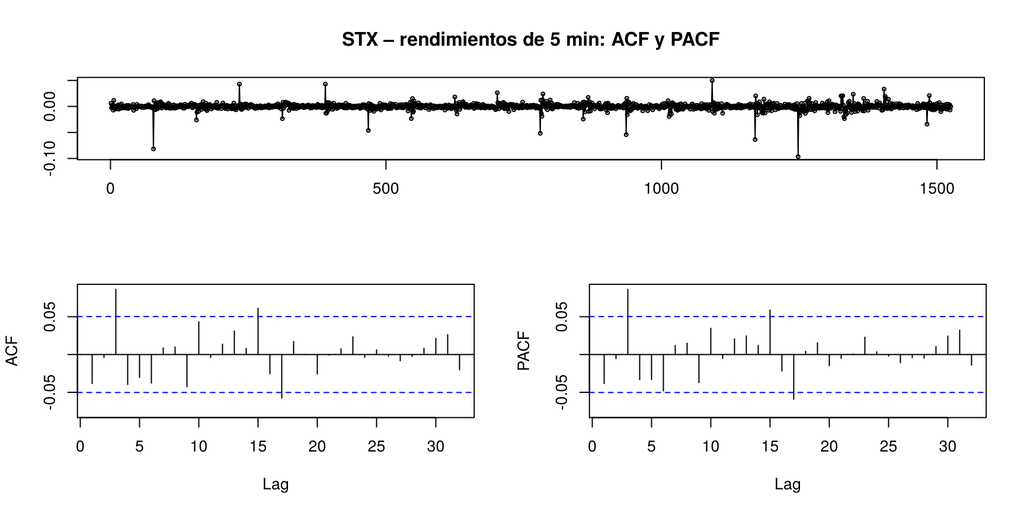

```
Series: ts(y)
ARIMA(0,1,3) with drift
Box Cox transformation: lambda= 0

Coefficients:
         ma1    ma2    ma3  drift
      -0.031  0.006  0.091      0
s.e.   0.026  0.027  0.026      0

sigma^2 = 0.0000444:  log likelihood = 5481
AIC=-10952   AICc=-10952   BIC=-10925
                   ME  RMSE   MAE      MPE   MAPE   MASE     ACF1
Training set 0.007913 4.056 2.062 -0.00182 0.3384 0.9916 -0.02527
```

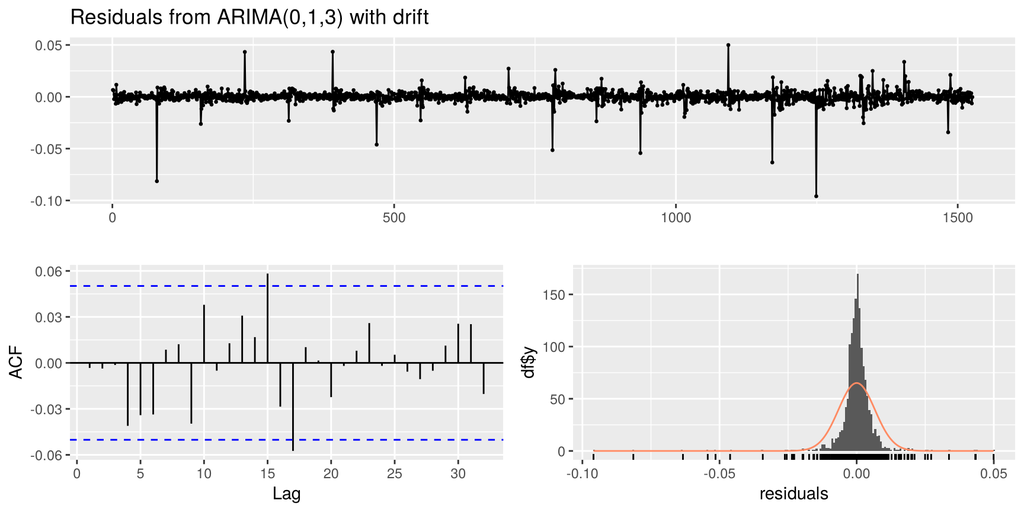

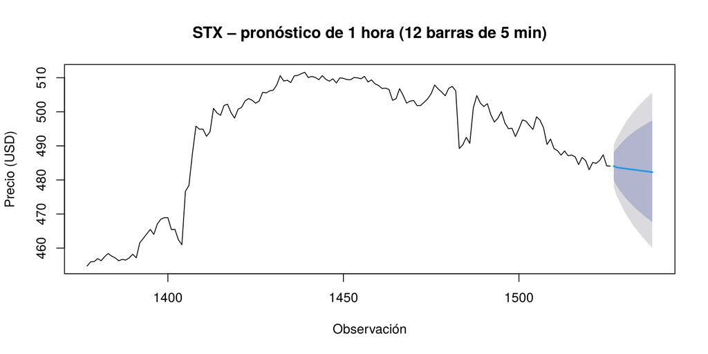

STX – pronóstico a 5 min

| paso | minutos | pronostico | li95 | ls95 |
| --- | --- | --- | --- | --- |
| 1 | 5 | 484.1 | 477.8 | 490.4 |
| 2 | 10 | 483.6 | 474.9 | 492.5 |
| 3 | 15 | 483.5 | 472.9 | 494.4 |
| 4 | 20 | 483.4 | 470.9 | 496.2 |
| 5 | 25 | 483.2 | 469.1 | 497.8 |
| 6 | 30 | 483.1 | 467.5 | 499.2 |
| 7 | 35 | 483.0 | 466.1 | 500.5 |
| 8 | 40 | 482.8 | 464.7 | 501.6 |
| 9 | 45 | 482.7 | 463.5 | 502.7 |
| 10 | 50 | 482.6 | 462.3 | 503.8 |
| 11 | 55 | 482.4 | 461.1 | 504.7 |
| 12 | 60 | 482.3 | 460.0 | 505.6 |

### 9.2.2 VLO – 5 minutos

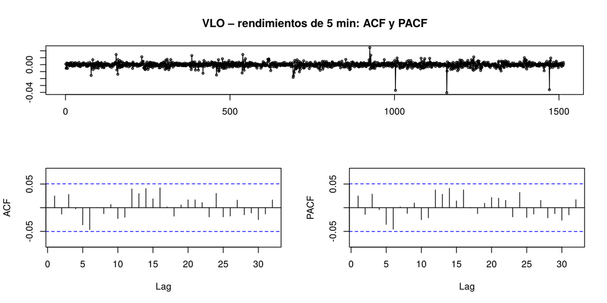

```
Series: ts(y)
ARIMA(2,1,3) with drift
Box Cox transformation: lambda= 0

Coefficients:
        ar1     ar2     ma1    ma2    ma3  drift
      0.374  -0.742  -0.348  0.727  0.057      0
s.e.  0.242   0.210   0.243  0.213  0.028      0

sigma^2 = 0.0000122:  log likelihood = 6422
AIC=-12831   AICc=-12831   BIC=-12794
                   ME  RMSE    MAE         MPE   MAPE MASE     ACF1
Training set 0.002572 1.384 0.8742 -0.00001944 0.2184    1 0.000341
```

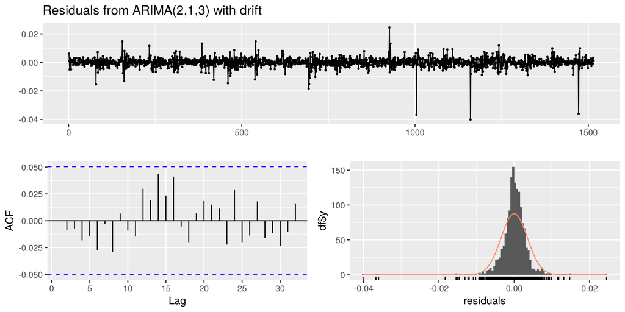

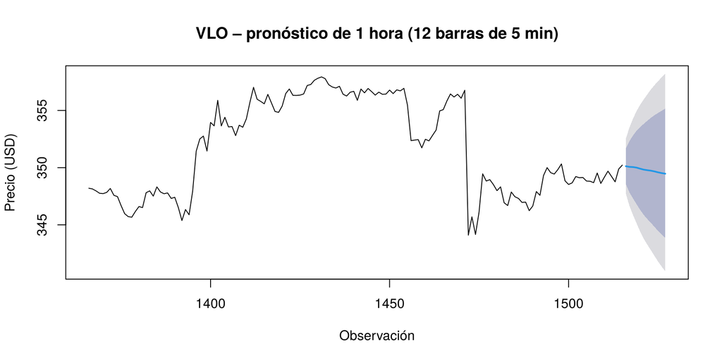

VLO – pronóstico a 5 min

| paso | minutos | pronostico | li95 | ls95 |
| --- | --- | --- | --- | --- |
| 1 | 5 | 350.1 | 347.7 | 352.5 |
| 2 | 10 | 350.1 | 346.6 | 353.5 |
| 3 | 15 | 350.1 | 345.9 | 354.3 |
| 4 | 20 | 350.0 | 345.1 | 354.9 |
| 5 | 25 | 349.9 | 344.4 | 355.5 |
| 6 | 30 | 349.8 | 343.8 | 356.0 |
| 7 | 35 | 349.8 | 343.3 | 356.4 |
| 8 | 40 | 349.7 | 342.8 | 356.8 |
| 9 | 45 | 349.7 | 342.3 | 357.2 |
| 10 | 50 | 349.6 | 341.8 | 357.6 |
| 11 | 55 | 349.5 | 341.4 | 357.9 |
| 12 | 60 | 349.5 | 340.9 | 358.2 |

### 9.2.3 DGX – 5 minutos

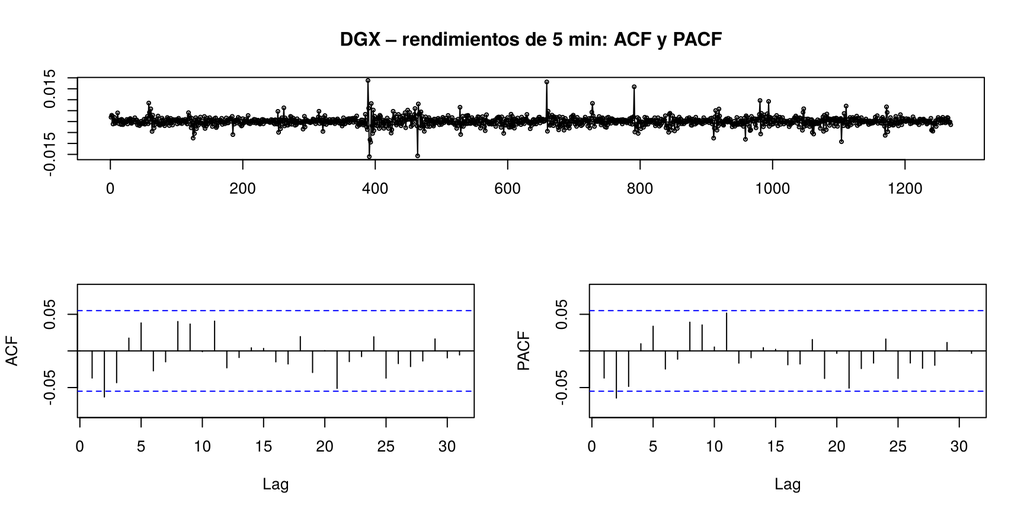

```
Series: ts(y)
ARIMA(3,1,0) with drift
Box Cox transformation: lambda= 0

Coefficients:
         ar1     ar2     ar3  drift
      -0.043  -0.066  -0.049      0
s.e.   0.028   0.028   0.028      0

sigma^2 = 0.0000046:  log likelihood = 6002
AIC=-11994   AICc=-11994   BIC=-11968
                   ME   RMSE   MAE       MPE   MAPE   MASE     ACF1
Training set 0.001163 0.5241 0.331 0.0002532 0.1352 0.9984 0.002439
```

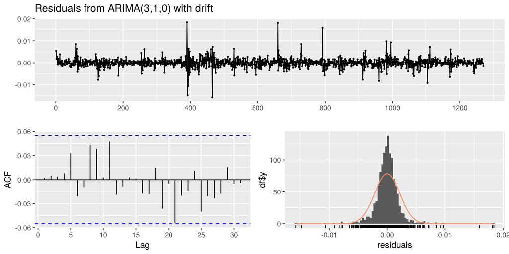

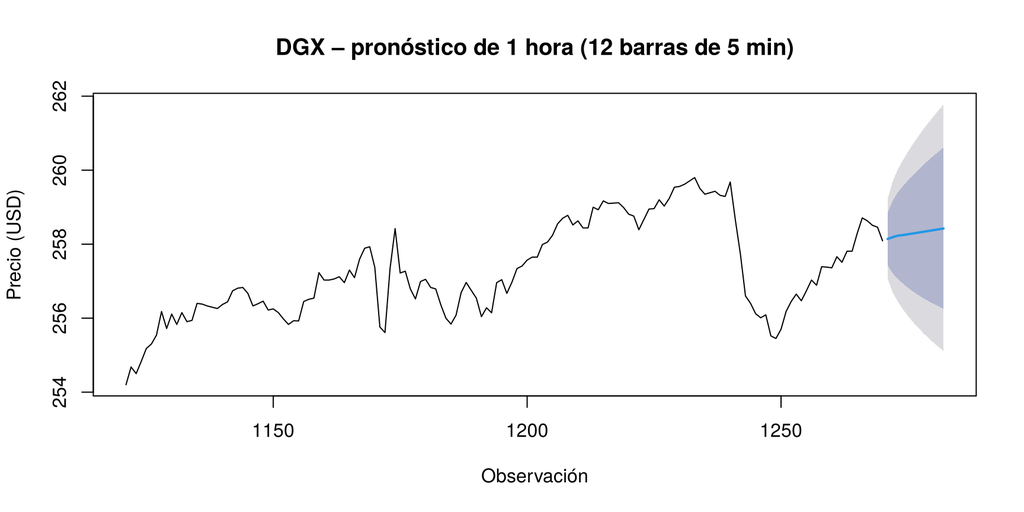

DGX – pronóstico a 5 min

| paso | minutos | pronostico | li95 | ls95 |
| --- | --- | --- | --- | --- |
| 1 | 5 | 258.1 | 257.1 | 259.2 |
| 2 | 10 | 258.2 | 256.7 | 259.7 |
| 3 | 15 | 258.2 | 256.4 | 260.0 |
| 4 | 20 | 258.2 | 256.2 | 260.3 |
| 5 | 25 | 258.3 | 256.1 | 260.5 |
| 6 | 30 | 258.3 | 255.9 | 260.7 |
| 7 | 35 | 258.3 | 255.7 | 260.9 |
| 8 | 40 | 258.3 | 255.6 | 261.1 |
| 9 | 45 | 258.4 | 255.5 | 261.3 |
| 10 | 50 | 258.4 | 255.3 | 261.4 |
| 11 | 55 | 258.4 | 255.2 | 261.6 |
| 12 | 60 | 258.4 | 255.1 | 261.8 |

### 9.2.4 NUE – 5 minutos

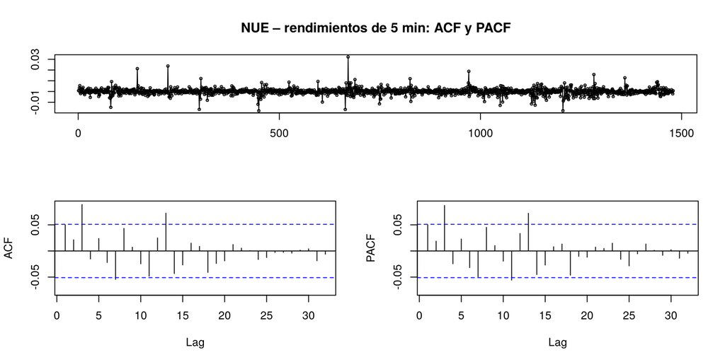

```
Series: ts(y)
ARIMA(0,1,3)
Box Cox transformation: lambda= 0

Coefficients:
        ma1    ma2    ma3
      0.050  0.013  0.094
s.e.  0.026  0.026  0.026

sigma^2 = 0.00000911:  log likelihood = 6487
AIC=-12966   AICc=-12966   BIC=-12945
                   ME   RMSE    MAE      MPE   MAPE   MASE       ACF1
Training set 0.003763 0.7895 0.4878 0.001106 0.1861 0.9984 -0.0003978
```

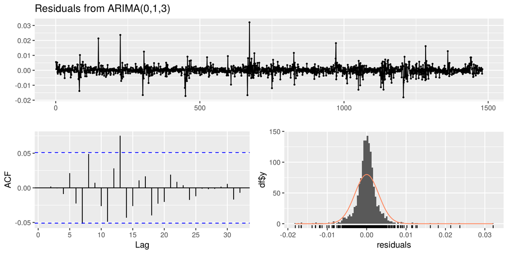

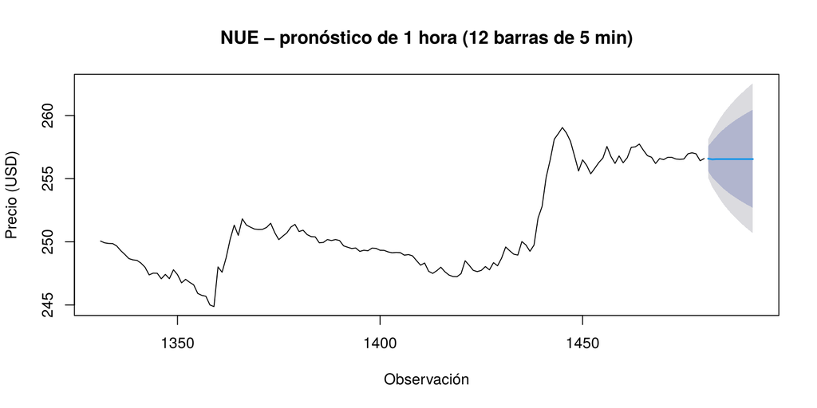

NUE – pronóstico a 5 min

| paso | minutos | pronostico | li95 | ls95 |
| --- | --- | --- | --- | --- |
| 1 | 5 | 256.6 | 255.1 | 258.1 |
| 2 | 10 | 256.5 | 254.3 | 258.7 |
| 3 | 15 | 256.6 | 253.8 | 259.3 |
| 4 | 20 | 256.6 | 253.3 | 259.8 |
| 5 | 25 | 256.6 | 252.9 | 260.3 |
| 6 | 30 | 256.6 | 252.5 | 260.7 |
| 7 | 35 | 256.6 | 252.1 | 261.0 |
| 8 | 40 | 256.6 | 251.8 | 261.4 |
| 9 | 45 | 256.6 | 251.5 | 261.7 |
| 10 | 50 | 256.6 | 251.2 | 262.0 |
| 11 | 55 | 256.6 | 250.9 | 262.3 |
| 12 | 60 | 256.6 | 250.7 | 262.6 |

### 9.2.5 CPAY – 5 minutos

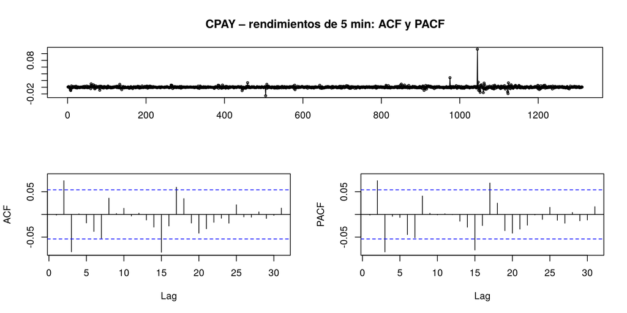

```
Series: ts(y)
ARIMA(0,1,3)
Box Cox transformation: lambda= 0

Coefficients:
        ma1    ma2     ma3
      0.005  0.075  -0.089
s.e.  0.027  0.027   0.029

sigma^2 = 0.0000162:  log likelihood = 5379
AIC=-10749   AICc=-10749   BIC=-10729
                  ME  RMSE   MAE    MPE   MAPE   MASE       ACF1
Training set 0.04854 1.745 0.679 0.0106 0.1618 0.9918 -0.0001011
```

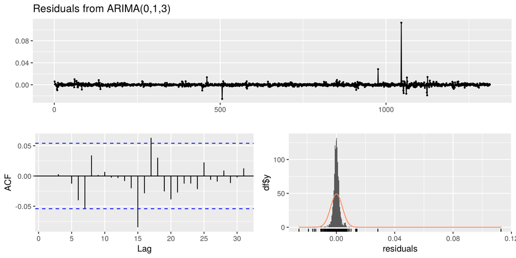

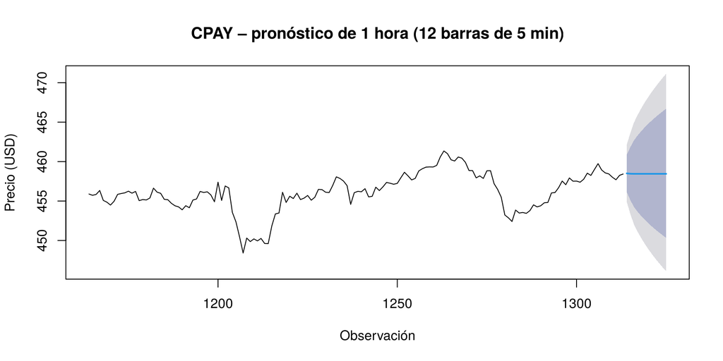

CPAY – pronóstico a 5 min

| paso | minutos | pronostico | li95 | ls95 |
| --- | --- | --- | --- | --- |
| 1 | 5 | 458.5 | 454.9 | 462.1 |
| 2 | 10 | 458.5 | 453.4 | 463.6 |
| 3 | 15 | 458.4 | 452.1 | 464.9 |
| 4 | 20 | 458.4 | 451.1 | 465.9 |
| 5 | 25 | 458.4 | 450.3 | 466.7 |
| 6 | 30 | 458.4 | 449.6 | 467.5 |
| 7 | 35 | 458.4 | 448.9 | 468.2 |
| 8 | 40 | 458.4 | 448.3 | 468.8 |
| 9 | 45 | 458.4 | 447.7 | 469.5 |
| 10 | 50 | 458.4 | 447.1 | 470.1 |
| 11 | 55 | 458.4 | 446.6 | 470.6 |
| 12 | 60 | 458.4 | 446.1 | 471.1 |

## 9.3 ARIMA de horas seleccionadas (cada 2 horas)

````r
res_2h <- list()
for (t in SELECCION) {
  x <- serie_2h[[t]]
  r <- analizar_arima(x, t, "2 horas", H_2H)
  res_2h[[t]] <- r
  cat(sprintf("\n\n### %s – cada 2 horas (10, 12, 14 y 16 h)\n\n", t))
  forecast::tsdisplay(diff(log(as.numeric(x))), main = paste(t, "– rendimientos cada 2 h: ACF y PACF"))
  cat("\n\n```\n"); print(r$fit); print(forecast::accuracy(r$fit)); cat("```\n\n")
  forecast::checkresiduals(r$fit, test = FALSE)
  plot(r$fc, include = 120, main = paste(t, "– pronóstico del siguiente día (4 obs. de 2 h)"),
       ylab = "Precio (USD)", xlab = "Observación")
  cat("\n\n")
  print(knitr::kable(data.frame(paso = 1:H_2H, hora = paste0(HORAS_2H[1:H_2H], ":00"),
                                pronostico = as.numeric(r$fc$mean),
                                li95 = as.numeric(r$fc$lower[, 2]), ls95 = as.numeric(r$fc$upper[, 2])),
                     digits = 2, caption = paste(t, "– pronóstico cada 2 h")))
}
````

### 9.3.1 STX – cada 2 horas (10, 12, 14 y 16 h)

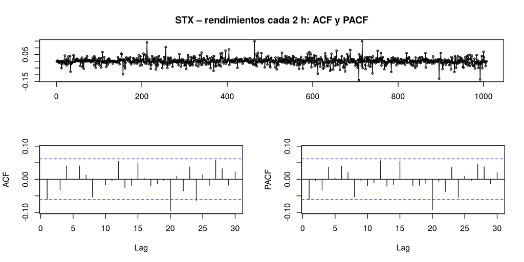

```
Series: ts(y)
ARIMA(0,1,1)
Box Cox transformation: lambda= 0

Coefficients:
         ma1
      -0.061
s.e.   0.032

sigma^2 = 0.000682:  log likelihood = 2242
AIC=-4481   AICc=-4481   BIC=-4471
                 ME  RMSE   MAE     MPE  MAPE   MASE     ACF1
Training set 0.2161 17.85 11.02 0.01933 1.752 0.9954 -0.02202
```

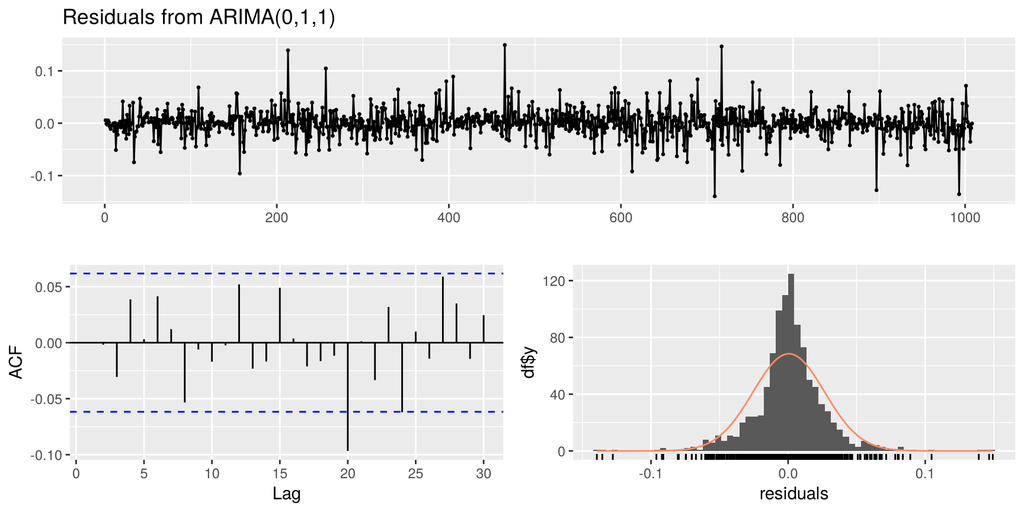

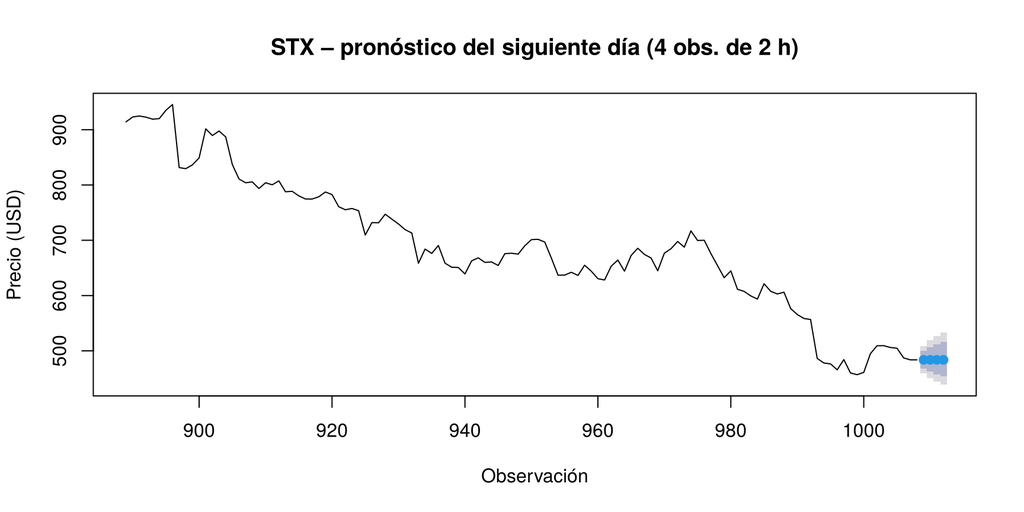

STX – pronóstico cada 2 h

| paso | hora | pronostico | li95 | ls95 |
| --- | --- | --- | --- | --- |
| 1 | 10:00 | 483.8 | 459.6 | 509.2 |
| 2 | 12:00 | 483.8 | 451.0 | 519.0 |
| 3 | 14:00 | 483.8 | 444.3 | 526.7 |
| 4 | 16:00 | 483.8 | 438.7 | 533.4 |

### 9.3.2 VLO – cada 2 horas (10, 12, 14 y 16 h)

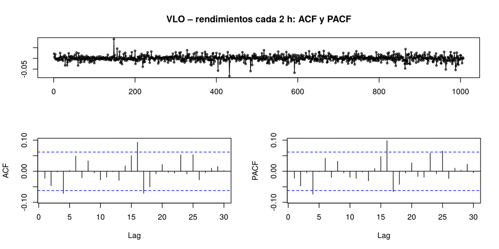

```
Series: ts(y)
ARIMA(1,1,1) with drift
Box Cox transformation: lambda= 0

Coefficients:
        ar1     ma1  drift
      0.690  -0.731  0.001
s.e.  0.206   0.195  0.000

sigma^2 = 0.000176:  log likelihood = 2926
AIC=-5845   AICc=-5845   BIC=-5825
                    ME  RMSE   MAE       MPE   MAPE   MASE    ACF1
Training set -0.007576 3.785 2.526 -0.007816 0.9221 0.9982 0.01277
```

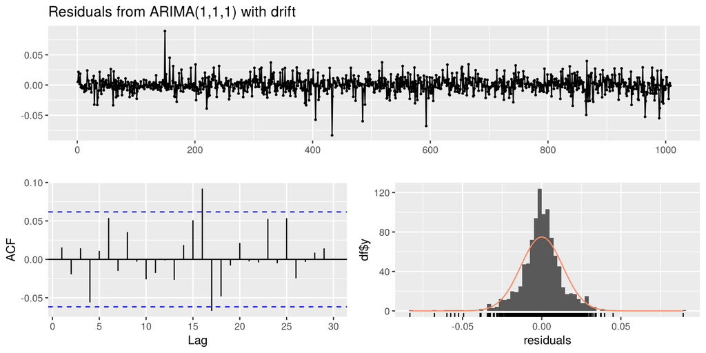

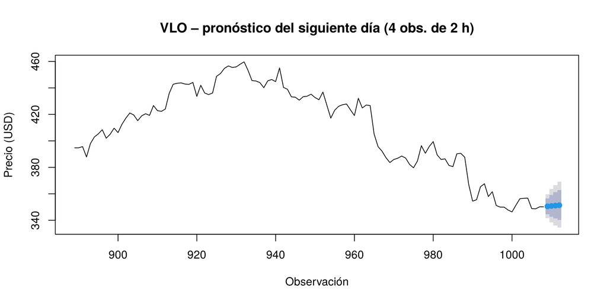

VLO – pronóstico cada 2 h

| paso | hora | pronostico | li95 | ls95 |
| --- | --- | --- | --- | --- |
| 1 | 10:00 | 350.5 | 341.5 | 359.7 |
| 2 | 12:00 | 350.8 | 338.4 | 363.7 |
| 3 | 14:00 | 351.1 | 336.2 | 366.7 |
| 4 | 16:00 | 351.4 | 334.4 | 369.2 |

### 9.3.3 DGX – cada 2 horas (10, 12, 14 y 16 h)

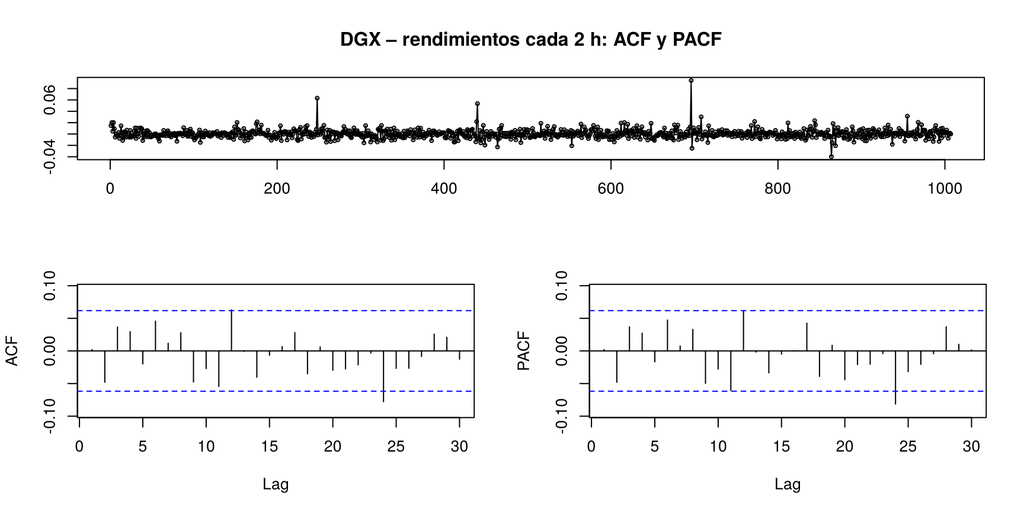

```
Series: ts(y)
ARIMA(4,1,0)
Box Cox transformation: lambda= 0

Coefficients:
        ar1     ar2    ar3    ar4
      0.005  -0.044  0.039  0.029
s.e.  0.032   0.032  0.032  0.032

sigma^2 = 0.0000621:  log likelihood = 3451
AIC=-6892   AICc=-6892   BIC=-6867
                  ME  RMSE   MAE     MPE   MAPE   MASE     ACF1
Training set 0.07858 1.665 1.084 0.03365 0.5188 0.9976 -0.01308
```

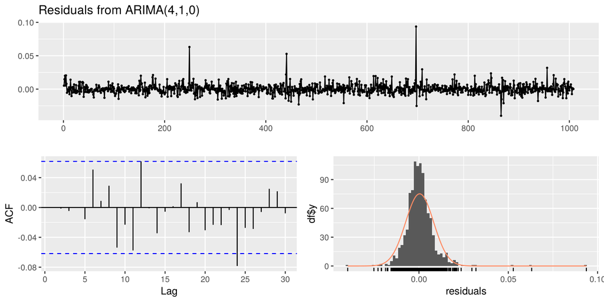

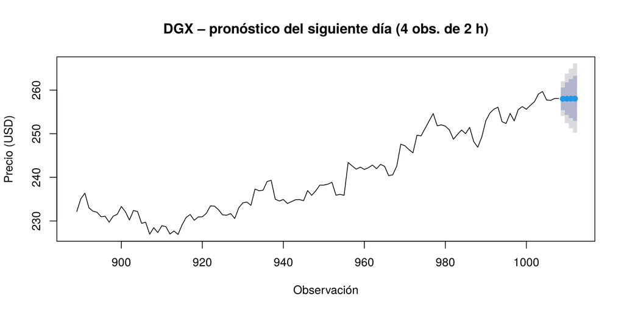

DGX – pronóstico cada 2 h

| paso | hora | pronostico | li95 | ls95 |
| --- | --- | --- | --- | --- |
| 1 | 10:00 | 258 | 254.1 | 262.0 |
| 2 | 12:00 | 258 | 252.4 | 263.7 |
| 3 | 14:00 | 258 | 251.3 | 265.0 |
| 4 | 16:00 | 258 | 250.3 | 266.1 |

### 9.3.4 NUE – cada 2 horas (10, 12, 14 y 16 h)

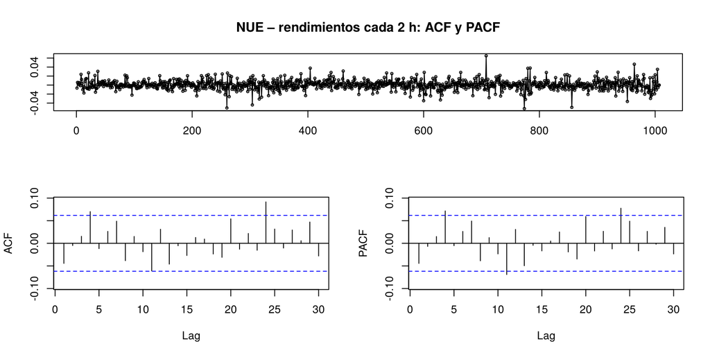

```
Series: ts(y)
ARIMA(0,1,4) with drift
Box Cox transformation: lambda= 0

Coefficients:
         ma1     ma2    ma3    ma4  drift
      -0.044  -0.008  0.010  0.076  0.001
s.e.   0.032   0.031  0.031  0.033  0.000

sigma^2 = 0.000114:  log likelihood = 3147
AIC=-6281   AICc=-6281   BIC=-6252
                   ME  RMSE   MAE       MPE   MAPE   MASE   ACF1
Training set -0.01053 2.399 1.631 -0.005055 0.7522 0.9994 0.0115
```

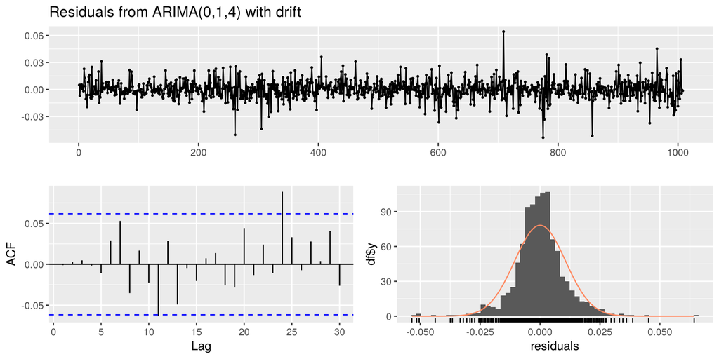

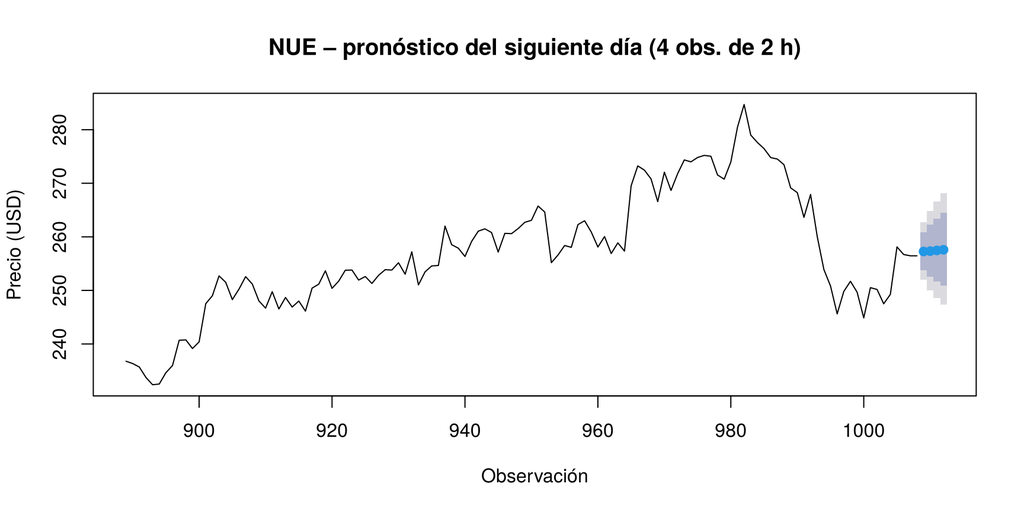

NUE – pronóstico cada 2 h

| paso | hora | pronostico | li95 | ls95 |
| --- | --- | --- | --- | --- |
| 1 | 10:00 | 257.3 | 251.9 | 262.7 |
| 2 | 12:00 | 257.3 | 250.0 | 264.9 |
| 3 | 14:00 | 257.5 | 248.6 | 266.6 |
| 4 | 16:00 | 257.6 | 247.4 | 268.2 |